# grupo-zap-data-challenge

## Grupo Zap: Data Science Challenge

Esse notebook aborda o desenvolvimento de um modelo para previsão dos valores do imóveis de um conjunto de dados composto por várias características de cada imóvel.

**Autor**: Raphael Brito Alencar  
**Linguagem**: Python  
**Tipo do problema**: Regressão  
**Métrica**: Root Mean Squared Logarithmic Error

```python
import pandas as pd
from pandas.io.json import json_normalize
import json
import matplotlib.pyplot as plt
import seaborn as sns
import numpy as np
import math
from scipy.stats import norm
from sklearn.preprocessing import StandardScaler
from scipy import stats
from scipy.special import boxcox1p
import gc
import warnings

warnings.filterwarnings('ignore')

%matplotlib inline
```

**Carregando dados**

- Base de amostras dos anúncios
- Possível anúncio de venda, aluguel ou ambos, preenchendo algumas características sobre o imóvel
- Os anúncios estão disponíveis em um arquivo no formato JSON, onde cada linha do arquivo é um JSON

```python
# arquivo .json com um nested json por linha
def create_df_from_json(file_path):
    with open(file_path) as f:
        object_list = [json.loads(line) for line in f.readlines()]

    return json_normalize(object_list, sep='_')
```

```python
train = create_df_from_json('../input/source-4-ds-train.json')
test = create_df_from_json('../input/source-4-ds-test.json')
results = pd.read_csv("../input/results.csv")

print('Train shape: ', train.shape)
print('Test shape: ', test.shape)
```

```
Train shape:  (133964, 37)
Test shape:  (16036, 37)
```

Vamos colocar os ids da base de teste no csv de resultados:

```python
results['id'] = test['id']
results.shape
```

```
(16036, 2)
```

```python
train.head()
```

|  | address_city | address_country | address_district | address_geoLocation_location_lat | address_geoLocation_location_lon | address_geoLocation_precision | address_locationId | address_neighborhood | address_state | address_street | address_streetNumber | address_unitNumber | address_zipCode | address_zone | bathrooms | bedrooms | createdAt | description | id | images | listingStatus | owner | parkingSpaces | pricingInfos_businessType | pricingInfos_monthlyCondoFee | pricingInfos_period | pricingInfos_price | pricingInfos_rentalTotalPrice | pricingInfos_yearlyIptu | … |
| --- | --- | --- | --- | --- | --- | --- | --- | --- | --- | --- | --- | --- | --- | --- | --- | --- | --- | --- | --- | --- | --- | --- | --- | --- | --- | --- | --- | --- | --- | --- |
| 0 | São Paulo | BR |  | -23.612923 | -46.614222 | ROOFTOP | BR>Sao Paulo>NULL>Sao Paulo>Zona Sul>Jardim da... | Jardim da Saúde | São Paulo | Rua Juvenal Galeno | 53 |  | 04290030 | Zona Sul | 3.0 | 4.0 | 2017-02-07T13:21:40Z | 04 dorms sendo 01 suíte e closet, sala de esta... | 787c7bd19d | [https://s3-sa-east-1.amazonaws.com/vr.images.... | ACTIVE | False | 6.0 | SALE | NaN | NaN | 700000 | NaN | NaN | … |
| 1 | São Paulo | BR |  | -23.643962 | -46.593475 | RANGE_INTERPOLATED | BR>Sao Paulo>NULL>Sao Paulo>Zona Sul>Vila Liviero | Vila Santa Teresa (Zona Sul) | São Paulo | Rua Juruaba | 16 |  | 04187320 | Zona Sul | 2.0 | 3.0 | 2016-03-21T18:35:17Z | 03 dorms sendo 01 suíte, sala, sala de jantar,... | 4d68c0cdbe | [https://s3-sa-east-1.amazonaws.com/vr.images.... | ACTIVE | False | 2.0 | SALE | NaN | NaN | 336000 | NaN | NaN | … |
| 2 | São Paulo |  |  | -23.568559 | -46.647452 | ROOFTOP | BR>Sao Paulo>NULL>Sao Paulo>Centro>Cerqueira C... | Bela Vista | São Paulo | Avenida Paulista | 402 |  | 01311000 |  | 4.0 | 0.0 | 2018-12-18T23:47:03.425Z | Andar com 395,70m² de área útil, 04 wcs, 05 va... | e7e0b554ac | [http://static.nidoimovel.com.br/d3d9446802a44... | ACTIVE | False | 5.0 | RENTAL | 4900.0 | MONTHLY | 24929 | 29829.0 | 4040.0 | … |
| 3 | São Paulo |  |  | -23.598023 | -46.682781 | RANGE_INTERPOLATED | BR>Sao Paulo>NULL>Sao Paulo>Zona Sul>Vila Olimpia | Vila Olímpia | São Paulo | Rua Alvorada | 1190 |  | 04550004 |  | 2.0 | 3.0 | 2018-10-26T16:18:28.915Z | Viva melhor e de um jeito novo, com privilégio... | 6654d93423 | [https://vr-prod-vivapro-images.s3.amazonaws.c... | ACTIVE | False | 2.0 | SALE | 686.0 | NaN | 739643 | NaN | 1610.0 | … |
| 4 | São Paulo |  |  | -23.582497 | -46.653027 | RANGE_INTERPOLATED | BR>Sao Paulo>NULL>Sao Paulo>Zona Sul>Paraiso | Paraíso | São Paulo | Rua Curitiba | 380 |  | 04005030 |  | 5.0 | 4.0 | 2018-12-14T18:06:51.342Z | Sua área é ocupada majoritariamente por instit... | 9ffaf676ae | [https://vr-prod-vivapro-images.s3.amazonaws.c... | ACTIVE | False | 5.0 | SALE | 6230.0 | NaN | 7520099 | NaN | 18900.0 | … |

```python
train.columns
```

```
Index(['address_city', 'address_country', 'address_district',
       'address_geoLocation_location_lat', 'address_geoLocation_location_lon',
       'address_geoLocation_precision', 'address_locationId',
       'address_neighborhood', 'address_state', 'address_street',
       'address_streetNumber', 'address_unitNumber', 'address_zipCode',
       'address_zone', 'bathrooms', 'bedrooms', 'createdAt', 'description',
       'id', 'images', 'listingStatus', 'owner', 'parkingSpaces',
       'pricingInfos_businessType', 'pricingInfos_monthlyCondoFee',
       'pricingInfos_period', 'pricingInfos_price',
       'pricingInfos_rentalTotalPrice', 'pricingInfos_yearlyIptu',
       'publicationType', 'publisherId', 'suites', 'title', 'totalAreas',
       'unitTypes', 'updatedAt', 'usableAreas'],
      dtype='object')
```

```python
print("A base de treino é composta por {} colunas numéricas e {} colunas categóricas".format(
    list(train.select_dtypes(include=[np.number]).shape)[1],
    list(train.select_dtypes(include = ['object']).shape)[1]))
```

```
A base de treino é composta por 12 colunas numéricas e 24 colunas categóricas
```

```python
train.info()
```

```
<class 'pandas.core.frame.DataFrame'>
RangeIndex: 133964 entries, 0 to 133963
Data columns (total 37 columns):
address_city                        133964 non-null object
address_country                     133964 non-null object
address_district                    133964 non-null object
address_geoLocation_location_lat    133953 non-null float64
address_geoLocation_location_lon    133953 non-null float64
address_geoLocation_precision       133953 non-null object
address_locationId                  133964 non-null object
address_neighborhood                133964 non-null object
address_state                       133964 non-null object
address_street                      133964 non-null object
address_streetNumber                133964 non-null object
address_unitNumber                  133964 non-null object
address_zipCode                     133964 non-null object
address_zone                        133964 non-null object
bathrooms                           133051 non-null float64
bedrooms                            130945 non-null float64
createdAt                           133964 non-null object
description                         133964 non-null object
id                                  133964 non-null object
images                              133964 non-null object
listingStatus                       133964 non-null object
owner                               133964 non-null bool
parkingSpaces                       129539 non-null float64
pricingInfos_businessType           133964 non-null object
pricingInfos_monthlyCondoFee        117127 non-null float64
pricingInfos_period                 29051 non-null object
pricingInfos_price                  133964 non-null int64
pricingInfos_rentalTotalPrice       28714 non-null float64
pricingInfos_yearlyIptu             114612 non-null float64
publicationType                     133964 non-null object
publisherId                         133964 non-null object
suites                              120347 non-null float64
title                               133964 non-null object
totalAreas                          91132 non-null float64
unitTypes                           133964 non-null object
updatedAt                           127367 non-null object
usableAreas                         133211 non-null float64
dtypes: bool(1), float64(11), int64(1), object(24)
memory usage: 36.9+ MB
```

Vamos verificar o quanto cada coluna está preenchida, ou seja, qual a porcentagem de registros não nulos de cada feature:

```python
missing_df = train.isnull().sum(axis=0).reset_index()
missing_df.columns = ['variable', 'missing values']
missing_df['filling factor (%)']=(train.shape[0]-missing_df['missing values'])/train.shape[0]*100
missing_df.sort_values('filling factor (%)').reset_index(drop = True)
```

|  | variable | missing values | filling factor (%) |
| --- | --- | --- | --- |
| 0 | pricingInfos_rentalTotalPrice | 105250 | 21.434117 |
| 1 | pricingInfos_period | 104913 | 21.685677 |
| 2 | totalAreas | 42832 | 68.027231 |
| 3 | pricingInfos_yearlyIptu | 19352 | 85.554328 |
| 4 | pricingInfos_monthlyCondoFee | 16837 | 87.431698 |
| 5 | suites | 13617 | 89.835329 |
| 6 | updatedAt | 6597 | 95.075543 |
| 7 | parkingSpaces | 4425 | 96.696874 |
| 8 | bedrooms | 3019 | 97.746409 |
| 9 | bathrooms | 913 | 99.318474 |
| 10 | usableAreas | 753 | 99.437909 |
| 11 | address_geoLocation_precision | 11 | 99.991789 |
| 12 | address_geoLocation_location_lon | 11 | 99.991789 |
| 13 | address_geoLocation_location_lat | 11 | 99.991789 |
| 14 | publisherId | 0 | 100.000000 |
| 15 | pricingInfos_price | 0 | 100.000000 |
| 16 | title | 0 | 100.000000 |
| 17 | pricingInfos_businessType | 0 | 100.000000 |
| 18 | unitTypes | 0 | 100.000000 |
| 19 | publicationType | 0 | 100.000000 |
| 20 | owner | 0 | 100.000000 |
| 21 | address_city | 0 | 100.000000 |
| 22 | images | 0 | 100.000000 |
| 23 | description | 0 | 100.000000 |
| 24 | createdAt | 0 | 100.000000 |
| 25 | address_zone | 0 | 100.000000 |
| 26 | address_zipCode | 0 | 100.000000 |
| 27 | address_unitNumber | 0 | 100.000000 |
| 28 | address_streetNumber | 0 | 100.000000 |
| 29 | address_street | 0 | 100.000000 |
| 30 | address_state | 0 | 100.000000 |
| 31 | address_neighborhood | 0 | 100.000000 |
| 32 | address_locationId | 0 | 100.000000 |
| 33 | address_district | 0 | 100.000000 |
| 34 | address_country | 0 | 100.000000 |
| 35 | listingStatus | 0 | 100.000000 |
| 36 | id | 0 | 100.000000 |

De acordo com a tabela acima é possível verificar que temos uma grande quantidade de valores nulos. Vamos tratar esses dados, em ambos contuntos de treinamento e teste, durante nossa análise, para conseguirmos plotar melhores gráficos e melhor entender o funcionamento de cada feature.

### Explorando os dados

Vamos começar analisando os tipos de unidade e deixar somente o que nos interessa.

**unitType**

```python
train['unitTypes'].value_counts()
```

```
APARTMENT                     72241
TWO_STORY_HOUSE               18068
HOME                           9030
OFFICE                         7714
FLAT                           7661
COMMERCIAL_PROPERTY            5871
CONDOMINIUM                    4015
PENTHOUSE                      2772
SHED_DEPOSIT_WAREHOUSE         2197
RESIDENTIAL_ALLOTMENT_LAND     1430
COMMERCIAL_ALLOTMENT_LAND       807
STORE                           694
BUSINESS                        663
KITNET                          522
RESIDENTIAL_BUILDING            142
COMMERCIAL_BUILDING              85
CLINIC                           33
FARM                             10
COUNTRY_HOUSE                     9
Name: unitTypes, dtype: int64
```

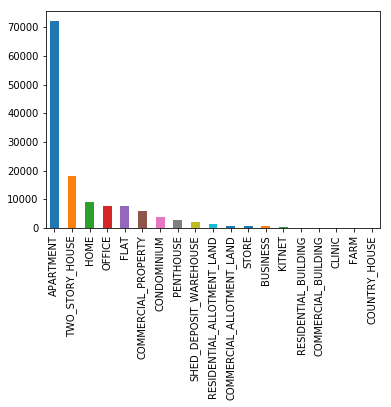

```python
train['unitTypes'].value_counts().plot.bar()
plt.show()
```

O único tipo que nos importa é o APARTMENT, então vamos excluir os outros tipos de unidades filtrando apenas os que nos interessa:

```python
q = 'unitTypes != "APARTMENT"'
train.query(q).head()
```

|  | address_city | address_country | address_district | address_geoLocation_location_lat | address_geoLocation_location_lon | address_geoLocation_precision | address_locationId | address_neighborhood | address_state | address_street | address_streetNumber | address_unitNumber | address_zipCode | address_zone | bathrooms | bedrooms | createdAt | description | id | images | listingStatus | owner | parkingSpaces | pricingInfos_businessType | pricingInfos_monthlyCondoFee | pricingInfos_period | pricingInfos_price | pricingInfos_rentalTotalPrice | pricingInfos_yearlyIptu | … |
| --- | --- | --- | --- | --- | --- | --- | --- | --- | --- | --- | --- | --- | --- | --- | --- | --- | --- | --- | --- | --- | --- | --- | --- | --- | --- | --- | --- | --- | --- | --- |
| 0 | São Paulo | BR |  | -23.612923 | -46.614222 | ROOFTOP | BR>Sao Paulo>NULL>Sao Paulo>Zona Sul>Jardim da... | Jardim da Saúde | São Paulo | Rua Juvenal Galeno | 53 |  | 04290030 | Zona Sul | 3.0 | 4.0 | 2017-02-07T13:21:40Z | 04 dorms sendo 01 suíte e closet, sala de esta... | 787c7bd19d | [https://s3-sa-east-1.amazonaws.com/vr.images.... | ACTIVE | False | 6.0 | SALE | NaN | NaN | 700000 | NaN | NaN | … |
| 1 | São Paulo | BR |  | -23.643962 | -46.593475 | RANGE_INTERPOLATED | BR>Sao Paulo>NULL>Sao Paulo>Zona Sul>Vila Liviero | Vila Santa Teresa (Zona Sul) | São Paulo | Rua Juruaba | 16 |  | 04187320 | Zona Sul | 2.0 | 3.0 | 2016-03-21T18:35:17Z | 03 dorms sendo 01 suíte, sala, sala de jantar,... | 4d68c0cdbe | [https://s3-sa-east-1.amazonaws.com/vr.images.... | ACTIVE | False | 2.0 | SALE | NaN | NaN | 336000 | NaN | NaN | … |
| 2 | São Paulo |  |  | -23.568559 | -46.647452 | ROOFTOP | BR>Sao Paulo>NULL>Sao Paulo>Centro>Cerqueira C... | Bela Vista | São Paulo | Avenida Paulista | 402 |  | 01311000 |  | 4.0 | 0.0 | 2018-12-18T23:47:03.425Z | Andar com 395,70m² de área útil, 04 wcs, 05 va... | e7e0b554ac | [http://static.nidoimovel.com.br/d3d9446802a44... | ACTIVE | False | 5.0 | RENTAL | 4900.0 | MONTHLY | 24929 | 29829.0 | 4040.0 | … |
| 5 | São Paulo | BR |  | -23.603692 | -46.673550 | ROOFTOP | BR>Sao Paulo>NULL>Sao Paulo>Zona Sul>Moema | Vila Uberabinha | São Paulo | Rua Pintassilgo | 477 |  | 04514032 | Zona Sul | 0.0 | 1.0 | 2018-10-09T06:37:15.236Z | O Moema Comfort Residence tem apartamentos esp... | 4d96835e38 | [http://static.nidoimovel.com.br/05049e90fa4f5... | ACTIVE | False | 1.0 | RENTAL | 560.0 | MONTHLY | 1889 | 2450.0 | 87.0 | … |
| 7 | São Paulo |  |  | -23.578943 | -46.556802 | GEOMETRIC_CENTER | BR>Sao Paulo>NULL>Sao Paulo>Zona Leste>Vila Sa... | Vila Santa Clara | São Paulo | Rua Dona Luísa de Paiva Dias |  |  | 03274050 |  | 1.0 | 3.0 | 2018-04-16T15:28:09.667Z | 3 DORMITÓRIOS, (SENDO 1 SUÍTE COM MÓVEIS PLANE... | aad80ae86e | [http://www.nogueiraimoveisguarulhos.com.br/fo... | ACTIVE | False | 2.0 | SALE | 0.0 | NaN | 385000 | NaN | 0.0 | … |

```python
train.drop(train.query(q).index, inplace=True)
train.shape
```

```
(72241, 37)
```

**Address**

Vamos analisar os campos da feature **address**.  
**1) address_city**

```python
train['address_city'].value_counts()
```

```
São Paulo    72241
Name: address_city, dtype: int64
```

Percebemos que os anúncios disponíveis estão concentrados na cidade de São Paulo. Dessa forma, podemos remover essa coluna, pois ela não agregará no poder de predição

**2) address_state**

```python
train['address_state'].value_counts()
```

```
São Paulo         72036
SP                  203
Santa Catarina        1
                      1
Name: address_state, dtype: int64
```

Verificando os valores disponíveis para essa coluna, o único valor deveria ser São Paulo, pois a variável address_city já informa que só temos registros na cidade de São Paulo. Como apareceu um registro com valor Santa Catarina e um registro vazio, vamos observá-los mais de perto.

```python
q = 'address_state == "Santa Catarina" or address_state == ""'
train.query(q)
```

|  | address_city | address_country | address_district | address_geoLocation_location_lat | address_geoLocation_location_lon | address_geoLocation_precision | address_locationId | address_neighborhood | address_state | address_street | address_streetNumber | address_unitNumber | address_zipCode | address_zone | bathrooms | bedrooms | createdAt | description | id | images | listingStatus | owner | parkingSpaces | pricingInfos_businessType | pricingInfos_monthlyCondoFee | pricingInfos_period | pricingInfos_price | pricingInfos_rentalTotalPrice | pricingInfos_yearlyIptu | … |
| --- | --- | --- | --- | --- | --- | --- | --- | --- | --- | --- | --- | --- | --- | --- | --- | --- | --- | --- | --- | --- | --- | --- | --- | --- | --- | --- | --- | --- | --- | --- |
| 9681 | São Paulo | BR |  | -23.675852 | -46.734351 | GEOMETRIC_CENTER | BR>Sao Paulo>NULL>Sao Paulo>Zona Sul>Guarapiranga | Parque Alves de Lima |  | Avenida Guarapiranga |  |  | 04902005 |  | 1.0 | 2.0 | 2017-06-03T04:34:39.290Z | Excelente Negocio, Oportunidade No Bairro, Pro... | c62ef1aa06 | [http://www.fabiocoelhoimoveis.net/v2010/spane... | ACTIVE | False | 1.0 | SALE | 210.0 | NaN | 189000 | NaN | 0.0 | … |
| 9840 | São Paulo | BR |  | -23.479666 | -46.636727 | ROOFTOP | BR>Sao Paulo>NULL>Sao Paulo>Zona Norte>Lauzane... | Parque Mandaqui | Santa Catarina | Rua Maria José Pomar | 322 |  | 02436070 |  | 3.0 | 3.0 | 2017-04-01T14:07:52Z | Excepcional oportunidade de moradia no Lauzane... | 7f3012c770 | [https://s3-sa-east-1.amazonaws.com/vr.images.... | ACTIVE | False | 2.0 | SALE | 595.0 | NaN | 566300 | NaN | 1959.0 | … |

Obseravndo as outras características, como address_street e adress_neighborhood, percebe-se que os registros, na realidade, devem ter erro de input, pois são anúncios no estado de São Paulo. Essa coluna não faz mais sentido, pois ela só deveria ter um valor (São Paulo). A partir de agora a coluna andress_country também perde seu valor analítico pois todos os registros são no Brasil. Vamos deletar as colunas para que não interfiram em nossa previsão:

```python
train.drop(['address_city', 'address_state', 'address_country'], axis=1, inplace=True)
test.drop(['address_city', 'address_state', 'address_country'], axis=1, inplace=True)
```

Lembrando que essas variáveis não terão efeito prático para a nossa análise, dado que possuem o mesmo valor em todo conjunto de dados

```python
print('Train shape: ', train.shape)
print('Test shape: ', test.shape)
```

```
Train shape:  (72241, 34)
Test shape:  (16036, 34)
```

**3) geolocation**

```python
train['address_geoLocation_precision'].value_counts()
```

```
ROOFTOP               41774
GEOMETRIC_CENTER      20635
RANGE_INTERPOLATED     6513
APPROXIMATE            3293
NO_GEOCODE               18
Name: address_geoLocation_precision, dtype: int64
```

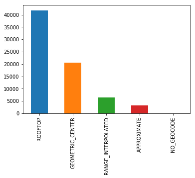

```python
train['address_geoLocation_precision'].value_counts().plot.bar()
plt.show()
```

Essa feature não parece nos dizer muita coisa sobre os valores dos dados, pois apenas indica a precisão da localização.

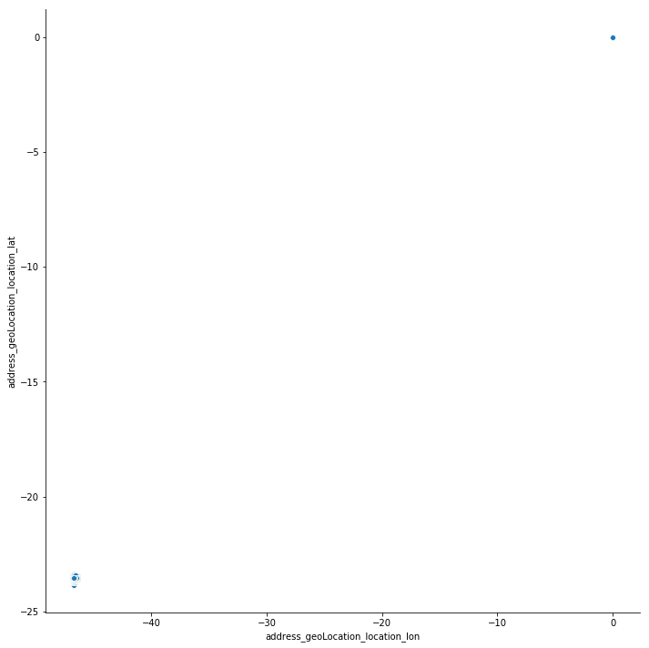

```python
sns.pairplot(x_vars=['address_geoLocation_location_lon'],
             y_vars=['address_geoLocation_location_lat'],
             data=train, size=10)
plt.show()
```

Plotando as latitudes e longitudes, percebesse que existe uma grande concetração entre as latitudes -25 e -20 e até a longitude -40, porém existe alguns pontos proximos da latitude e longitude 0. Vamos verificar que pontos são esses e decidir se devemos continuar com eles.

```python
q = '(address_geoLocation_location_lon > -10.00) & (address_geoLocation_location_lat > -10.00)'
train.query(q)
```

|  | address_district | address_geoLocation_location_lat | address_geoLocation_location_lon | address_geoLocation_precision | address_locationId | address_neighborhood | address_street | address_streetNumber | address_unitNumber | address_zipCode | address_zone | bathrooms | bedrooms | createdAt | description | id | images | listingStatus | owner | parkingSpaces | pricingInfos_businessType | pricingInfos_monthlyCondoFee | pricingInfos_period | pricingInfos_price | pricingInfos_rentalTotalPrice | pricingInfos_yearlyIptu | publicationType | publisherId | suites | … |
| --- | --- | --- | --- | --- | --- | --- | --- | --- | --- | --- | --- | --- | --- | --- | --- | --- | --- | --- | --- | --- | --- | --- | --- | --- | --- | --- | --- | --- | --- | --- |
| 10100 |  | 0.0 | 0.0 | NO_GEOCODE | BR>Sao Paulo>NULL>Sao Paulo>Zona Sul>Jardim Ta... | Jardim Taquaral | Rua José Jardim da Silveira |  |  | 04674230 | Zona Sul | 1.0 | 3.0 | 2014-11-26T17:14:20Z | Apartamento com ótima localização,com 3 dormit... | b24f9a50db | [https://s3-sa-east-1.amazonaws.com/vr.images.... | ACTIVE | False | 1.0 | RENTAL | NaN | MONTHLY | 2100 | 2100.0 | NaN | STANDARD | e69fe8aebc | 1.0 | … |
| 14954 |  | 0.0 | 0.0 | NO_GEOCODE | BR>Sao Paulo>NULL>Sao Paulo>Zona Sul>Moema | Moema | Rua Ministro Gabriel de Rezende Passos |  |  | 04521022 | Zona Sul | 3.0 | 2.0 | 2016-04-19T13:55:42Z | Moema - Perto de tudo - 242m², 2 suites com cl... | 53f3e11d54 | [https://s3-sa-east-1.amazonaws.com/vr.images.... | ACTIVE | False | 4.0 | RENTAL | 2100.0 | MONTHLY | 6160 | 8260.0 | 10500.0 | STANDARD | 3b141d677a | 2.0 | … |

Podemos deletá-los, dado que são poucos em relação ao universo de dados e não possuem informações relevantes para nossa análise. Outra abordagem, caso existissem mais pontos, seria utilizar o modulo do google maps com o pacote Client para retornar a lat e lon de acordo com o nome da rua, bairro, estado e etc, usando o código comentado na célula abaixo:

```python
# from googlemaps import Client
# gmaps = Client(API_KEY)
# lat, lng = gmaps.geocode(address)
```

```python
train.drop(train.query(q).index, inplace=True)
```

```python
print('Train shape: ', train.shape)
```

```
Train shape:  (72239, 34)
```

**4) address_neighborhood**

```python
train['address_neighborhood'].nunique()
```

```
1157
```

```python
train['address_neighborhood'].value_counts().nlargest(n=5)
```

```
Jardim Paulista    2298
Higienópolis       2075
Santana            1828
Pinheiros          1762
Vila Mariana       1746
Name: address_neighborhood, dtype: int64
```

```python
train['address_neighborhood'].value_counts().mean()
```

```
62.43647363872083
```

Os registros se distribuem em 1157 bairros diferentes. Sendo Jardim Paulista com o maior número de anúncios e uma média de 62.43 anúncios por bairro.

```python
len(train[train['address_neighborhood'] == ""])
```

```
13
```

**5) address_district**

```python
train['address_district'].value_counts()
```

```
           72236
Jaraguá        3
Name: address_district, dtype: int64
```

```python
train.drop(['address_district'], axis=1, inplace=True)
test.drop(['address_district'], axis=1, inplace=True)

print('Train shape: ', train.shape)
print('Test shape: ', test.shape)
```

```
Train shape:  (72239, 33)
Test shape:  (16036, 33)
```

**6) address_street e address_streetNumber**

```python
train['address_street'].value_counts().nlargest(n=5)
```

```
                                         3247
Rua Bela Cintra                           348
Rua Maranhão                              343
Rua Voluntários da Pátria                 339
Avenida Raimundo Pereira de Magalhães     307
Name: address_street, dtype: int64
```

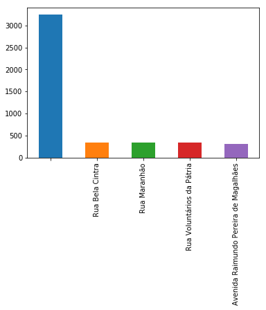

```python
train['address_street'].value_counts().nlargest(n=5).plot.bar()
plt.show()
```

```python
train.drop(['address_street'], axis=1, inplace=True)
test.drop(['address_street'], axis=1, inplace=True)

print('Train shape: ', train.shape)
print('Test shape: ', test.shape)
```

```
Train shape:  (72239, 32)
Test shape:  (16036, 32)
```

**7) address_unitNumber**

```python
train['address_unitNumber'].value_counts().nlargest(n=5)
```

```
                   72216
Apartamento            4
Dona Norma             1
Edifício Itaici        1
APTO 81                1
Name: address_unitNumber, dtype: int64
```

Coluna com maior parte dos registros em branco. Não será benéfica para nossa análise, podemos ingnorá-la.

```python
train.drop(['address_unitNumber'], axis=1, inplace=True)
test.drop(['address_unitNumber'], axis=1, inplace=True)

print('Train shape: ', train.shape)
print('Test shape: ', test.shape)
```

```
Train shape:  (72239, 31)
Test shape:  (16036, 31)
```

**8) address_zipCode**

```python
train['address_zipCode'].value_counts().nlargest(n=5)
```

```
            2864
00000000     986
02675031     369
05734140     207
01240001     202
Name: address_zipCode, dtype: int64
```

```python
train.drop(['address_zipCode'], axis=1, inplace=True)
test.drop(['address_zipCode'], axis=1, inplace=True)

print('Train shape: ', train.shape)
print('Test shape: ', test.shape)
```

```
Train shape:  (72239, 30)
Test shape:  (16036, 30)
```

**9) address_zone**

```python
train['address_zone'].value_counts()
```

```
              63453
Zona Sul       3022
Centro         1889
Zona Norte     1434
Zona Leste     1269
Zona Oeste     1172
Name: address_zone, dtype: int64
```

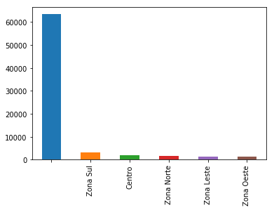

```python
train['address_zone'].value_counts().plot.bar()
plt.show()
```

Percebemos que existem milhares de valores faltantes, porém podemos preencher esses valores, consultando address_locationId.

```python
q = 'address_zone == ""'
train.query(q)
```

|  | address_geoLocation_location_lat | address_geoLocation_location_lon | address_geoLocation_precision | address_locationId | address_neighborhood | address_streetNumber | address_zone | bathrooms | bedrooms | createdAt | description | id | images | listingStatus | owner | parkingSpaces | pricingInfos_businessType | pricingInfos_monthlyCondoFee | pricingInfos_period | pricingInfos_price | pricingInfos_rentalTotalPrice | pricingInfos_yearlyIptu | publicationType | publisherId | suites | title | totalAreas | unitTypes | updatedAt | … |
| --- | --- | --- | --- | --- | --- | --- | --- | --- | --- | --- | --- | --- | --- | --- | --- | --- | --- | --- | --- | --- | --- | --- | --- | --- | --- | --- | --- | --- | --- | --- |
| 3 | -23.598023 | -46.682781 | RANGE_INTERPOLATED | BR>Sao Paulo>NULL>Sao Paulo>Zona Sul>Vila Olimpia | Vila Olímpia | 1190 |  | 2.0 | 3.0 | 2018-10-26T16:18:28.915Z | Viva melhor e de um jeito novo, com privilégio... | 6654d93423 | [https://vr-prod-vivapro-images.s3.amazonaws.c... | ACTIVE | False | 2.0 | SALE | 686.0 | NaN | 739643 | NaN | 1610.0 | STANDARD | 527c7b0cc0 | 1.0 | Apartamento com 80m², 2 vagas próximo ao Parqu... | 80.0 | APARTMENT | 2018-11-08T16:38:35.434Z | … |
| 4 | -23.582497 | -46.653027 | RANGE_INTERPOLATED | BR>Sao Paulo>NULL>Sao Paulo>Zona Sul>Paraiso | Paraíso | 380 |  | 5.0 | 4.0 | 2018-12-14T18:06:51.342Z | Sua área é ocupada majoritariamente por instit... | 9ffaf676ae | [https://vr-prod-vivapro-images.s3.amazonaws.c... | ACTIVE | False | 5.0 | SALE | 6230.0 | NaN | 7520099 | NaN | 18900.0 | STANDARD | 527c7b0cc0 | 4.0 | Apartamento 332m², 4 suítes à venda próximo ao... | 332.0 | APARTMENT | 2018-12-14T18:06:55.140Z | … |
| 6 | -23.561318 | -46.686355 | ROOFTOP | BR>Sao Paulo>NULL>Sao Paulo>Zona Oeste>Pinheiros | Pinheiros | 586 |  | 1.0 | 3.0 | 2018-05-29T18:11:31.347Z | Apartamento em ótimo bairro, bem localizado a ... | f03e22422a | [https://vr-prod-vivapro-images.s3.amazonaws.c... | ACTIVE | False | 2.0 | SALE | 1120.0 | NaN | 630700 | NaN | 489.0 | STANDARD | eab052c04f | 0.0 | APARTAMENTO EM PINHEIROS!!! | 0.0 | APARTMENT | 2018-11-08T12:57:03.132Z | … |
| 9 | -23.568103 | -46.628405 | RANGE_INTERPOLATED | BR>Sao Paulo>NULL>Sao Paulo>Centro>Aclimacao | Aclimação | 140 |  | 4.0 | 4.0 | 2019-01-09T18:40:00.306Z | O apartamento tem 141 metros quadrados está lo... | 8e1922c386 | [https://vr-prod-vivapro-images.s3.amazonaws.c... | ACTIVE | False | 2.0 | SALE | 0.0 | NaN | 1106000 | NaN | 0.0 | PREMIUM | a9891875dd | 3.0 | Apartamento para venda com 141 metros quadrado... | 141.0 | APARTMENT | 2019-01-09T18:48:43.900Z | … |
| 16 | -23.613883 | -46.626895 | RANGE_INTERPOLATED | BR>Sao Paulo>NULL>Sao Paulo>Zona Sul>Bosque da... | Bosque da Saúde | 01 |  | 2.0 | 2.0 | 2019-01-12T14:40:12.677Z | Apartamento semi novo, mobiliado água e gás in... | 3d756cfa06 | [https://vr-prod-vivapro-images.s3.amazonaws.c... | ACTIVE | False | 2.0 | SALE | 406.0 | NaN | 350000 | NaN | 118.0 | STANDARD | 93b018ea7d | 1.0 | Lindo apto, prox. Ao metrô, ensolarado, excele... | 66.0 | APARTMENT | 2019-01-12T14:40:15.015Z | … |
| 17 | -23.575314 | -46.737489 | ROOFTOP | BR>Sao Paulo>NULL>Sao Paulo>Zona Oeste>Vila Gomes | Vila Gomes | 159 |  | 1.0 | 2.0 | 2018-09-11T00:01:12.704Z | Um espaço voltado para o seu bem-estar: lazer ... | 7a7f945bf9 | [https://vr-prod-vivapro-images.s3.amazonaws.c... | ACTIVE | False | 1.0 | SALE | 244.0 | NaN | 252629 | NaN | 644.0 | STANDARD | 527c7b0cc0 | 0.0 | Apartamento à venda com 55m² e 2 dormitórios p... | 55.0 | APARTMENT | 2018-11-08T16:38:35.434Z | … |
| 21 | -23.664824 | -46.688407 | GEOMETRIC_CENTER | BR>Sao Paulo>NULL>Sao Paulo>Zona Sul>Jardim Ma... | Jardim Marajoara | 00 |  | 2.0 | 3.0 | 2019-01-18T19:28:01.526Z | Apartamento para Venda Jardim Marajoara, São P... | 47e9737aaa | [https://vr-prod-vivapro-images.s3.amazonaws.c... | ACTIVE | False | 1.0 | SALE | 489.0 | NaN | 406000 | NaN | 0.0 | STANDARD | 38e4c3862b | 1.0 | Apartamento 86 m² para Venda com 3 dormitórios... | 86.0 | APARTMENT | 2019-01-18T19:28:08.343Z | … |
| 23 | -23.516717 | -46.712707 | GEOMETRIC_CENTER | BR>Sao Paulo>NULL>Sao Paulo>Zona Oeste>Lapa | Lapa | 555 |  | 4.0 | 4.0 | 2018-06-07T18:57:10.552Z | Pronto para morar! Última unidade\n\nChegou a ... | 10b25e3090 | [https://vr-prod-vivapro-images.s3.amazonaws.c... | ACTIVE | False | 2.0 | SALE | 0.0 | NaN | 683200 | NaN | 0.0 | STANDARD | b6c56b723f | 2.0 | Apto 134 m² 3 ou 4 dorms, Closet, 2 suítes, ... | 134.0 | APARTMENT | 2018-12-13T16:27:39.232Z | … |
| 24 | -23.617101 | -46.757218 | RANGE_INTERPOLATED | BR>Sao Paulo>NULL>Sao Paulo>Zona Sul>Jardim Um... | Jardim Umarizal | 21 |  | 1.0 | 2.0 | 2018-01-19T11:30:52.702Z | Felipe\n Fone: - Nextel 55*97*132141 \n Whatss... | cbee3ce1f0 | [https://vr-prod-vivapro-images.s3.amazonaws.c... | ACTIVE | False | 1.0 | SALE | 210.0 | NaN | 157500 | NaN | 0.0 | STANDARD | a8b38b03a8 | 0.0 | Apartamento Atua Morumbi | 50.0 | APARTMENT | 2018-12-05T12:28:36.418Z | … |
| 25 | -23.598327 | -46.611316 | ROOFTOP | BR>Sao Paulo>NULL>Sao Paulo>Zona Sul>Vila Dom ... | Vila Dom Pedro I | 194 |  | 1.0 | 1.0 | 2019-01-14T23:06:29.958Z | Apartamento localizado no ótimo bairro do Ipir... | 2348891a0d | [https://vr-prod-vivapro-images.s3.amazonaws.c... | ACTIVE | False | 1.0 | SALE | 0.0 | NaN | 193900 | NaN | 0.0 | STANDARD | c3526e68e6 | 0.0 | Apartamento com 1 Dormitorio - 1 Banheiro - 44... | 44.0 | APARTMENT | 2019-01-14T23:16:19.328Z | … |
| 27 | -23.567793 | -46.687788 | ROOFTOP | BR>Sao Paulo>NULL>Sao Paulo>Zona Oeste>Pinheiros | Pinheiros | 1057 |  | 1.0 | 1.0 | 2018-12-08T17:49:57.896Z | Studios de 30 á 40m², flets de 24 á 41m² e apa... | 67739c76ff | [https://vr-prod-vivapro-images.s3.amazonaws.c... | ACTIVE | False | 0.0 | SALE | 280.0 | NaN | 230221 | NaN | 0.0 | STANDARD | c3526e68e6 | 1.0 | Apartamento em Pinheiros próximo a metrô | 40.0 | APARTMENT | 2018-12-08T17:50:00.598Z | … |
| 28 | -23.587600 | -46.488497 | GEOMETRIC_CENTER | BR>Sao Paulo>NULL>Sao Paulo>Zona Leste>Jardim ... | Jardim Nove de Julho |  |  | 1.0 | 2.0 | 2017-07-05T13:51:32.603Z | Lindo Apartamento para Venda - Jd. Nove de Jul... | 7ee2a005cb | [https://s3-sa-east-1.amazonaws.com/vr.images.... | ACTIVE | False | 1.0 | SALE | 161.0 | NaN | 175000 | NaN | 0.0 | STANDARD | 0801757c81 | 0.0 | Lindo Apartamento para Venda - Jd. Nove de Jul... | 45.0 | APARTMENT | 2019-01-10T13:18:09.414Z | … |
| 30 | -23.550673 | -46.596921 | ROOFTOP | BR>Sao Paulo>NULL>Sao Paulo>Zona Leste>Mooca | Móoca | 670 |  | 2.0 | 3.0 | 2018-10-05T17:39:22.037Z | Lindo Apartamento, mobiliado, decoração modern... | 571fcedf26 | [https://vr-prod-vivapro-images.s3.amazonaws.c... | ACTIVE | False | 1.0 | SALE | 394.0 | NaN | 385000 | NaN | 47.0 | STANDARD | 050a7d89dd | 1.0 | LINDO APARTAMENTO, CHARMOSO, MOBILIADO, IMPECÁ... | 0.0 | APARTMENT | 2018-11-08T16:02:29.198Z | … |
| 31 | -23.666044 | -46.717464 | RANGE_INTERPOLATED | BR>Sao Paulo>NULL>Sao Paulo>Zona Norte>Jardim ... | Jardim Japão | 516 |  | 1.0 | 3.0 | 2018-09-01T01:20:55.671Z | O apartamento tem 78 metros quadrados está loc... | ebf708842f | [https://vr-prod-vivapro-images.s3.amazonaws.c... | ACTIVE | False | 1.0 | SALE | 342.0 | NaN | 258299 | NaN | 0.0 | STANDARD | a8b38b03a8 | 0.0 | Apartamento para venda possui 78 metros quadra... | 78.0 | APARTMENT | 2018-12-05T12:13:04.995Z | … |
| 33 | -23.491670 | -46.629228 | RANGE_INTERPOLATED | BR>Sao Paulo>NULL>Sao Paulo>Zona Norte>Santana | Santana | 321 |  | 6.0 | 4.0 | 2017-08-17T16:40:29.247Z | Condomínio Piazza San Pietro esta numa das mel... | 3e6af42937 | [https://vr-prod-vivapro-images.s3.amazonaws.c... | ACTIVE | False | 4.0 | SALE | 909.0 | NaN | 1540000 | NaN | 4200.0 | STANDARD | 38d9d9e749 | 4.0 | CONDOMÍNIO PIAZZA SAN PIETRO- SANTANA SÃO PAULO | 16855.0 | APARTMENT | 2019-01-07T23:05:45.898Z | … |
| 34 | -23.597315 | -46.554757 | GEOMETRIC_CENTER | BR>Sao Paulo>NULL>Sao Paulo>Zona Leste>VILA AL... | Vila Alpina |  |  | 1.0 | 2.0 | 2018-12-05T10:13:27.021Z | O apartamento possui 70 metros.\n2 dormitórios... | cdb501c35c | [https://vr-prod-vivapro-images.s3.amazonaws.c... | ACTIVE | False | 1.0 | SALE | 280.0 | NaN | 161000 | NaN | 0.0 | STANDARD | 260ba927d4 | 0.0 | Apartamento para venda | 0.0 | APARTMENT | 2018-12-05T10:13:32.895Z | … |
| 35 | -23.534171 | -46.579155 | RANGE_INTERPOLATED | BR>Sao Paulo>NULL>Sao Paulo>Zona Leste>Tatuape | Tatuapé | 101 |  | 4.0 | 3.0 | 2018-12-26T15:41:44.949Z | No coração do Tatuapé:\n- 600 m do Parque do P... | 49255949c3 | [https://vr-prod-vivapro-images.s3.amazonaws.c... | ACTIVE | False | 2.0 | SALE | 0.0 | NaN | 427000 | NaN | 0.0 | STANDARD | c3526e68e6 | 3.0 | Apto 3 Suítes - Rua Ivai - The Gardens Reserva | 103.0 | APARTMENT | 2018-12-26T15:41:48.316Z | … |
| 36 | -23.568103 | -46.628405 | RANGE_INTERPOLATED | BR>Sao Paulo>NULL>Sao Paulo>Centro>Aclimacao | Aclimação | 140 |  | 4.0 | 4.0 | 2019-01-09T18:46:23.013Z | O apartamento tem 141 metros quadrados está lo... | 029392ddf8 | [https://vr-prod-vivapro-images.s3.amazonaws.c... | ACTIVE | False | 2.0 | SALE | 0.0 | NaN | 1106700 | NaN | 0.0 | PREMIUM | a9891875dd | 3.0 | Apartamento, para venda com 141 metros quadrad... | 141.0 | APARTMENT | 2019-01-09T18:49:03.814Z | … |
| 38 | -23.477879 | -46.708328 | ROOFTOP | BR>Sao Paulo>NULL>Sao Paulo>Zona Leste>Vila Re... | Vila Regina | 141 |  | 1.0 | 3.0 | 2018-06-23T12:34:10.930Z | Apartamento localizado em Pirituba (Condomínio... | 2fed985fde | [https://vr-prod-vivapro-images.s3.amazonaws.c... | ACTIVE | False | 1.0 | SALE | 244.0 | NaN | 171500 | NaN | 0.0 | STANDARD | b797f29a38 | 0.0 | APTO NO CONDOMÍNIO LA DOLCE VITA - 3 DORMS, 1... | 0.0 | APARTMENT | 2018-11-08T13:34:24.263Z | … |
| 41 | -23.627822 | -46.668190 | GEOMETRIC_CENTER | BR>Sao Paulo>NULL>Sao Paulo>Zona Sul>Campo Belo | Campo Belo |  |  | 3.0 | 3.0 | 2018-11-28T20:36:53.010Z | DESCRIÇÃO ADICIONAL: Sala ampliada, clara e co... | 7a31591e34 | [https://vr-prod-vivapro-images.s3.amazonaws.c... | ACTIVE | False | 2.0 | SALE | 700.0 | NaN | 742000 | NaN | 322.0 | STANDARD | 988265e3c6 | 1.0 | Apartamento em andar alto, totalmente reformad... | 0.0 | APARTMENT | 2019-01-28T11:59:29.865Z | … |
| 43 | -23.658699 | -46.690870 | ROOFTOP | BR>Sao Paulo>NULL>Sao Paulo>Zona Sul>Vila Sofia | Vila Sofia | 495 |  | 3.0 | 3.0 | 2018-12-13T14:44:23.334Z | Apartamento face norte (sol o dia todo); recém... | ac2c8cb380 | [https://vr-prod-vivapro-images.s3.amazonaws.c... | ACTIVE | False | 1.0 | SALE | 864.0 | NaN | 441000 | NaN | 11.0 | STANDARD | 35f822db1b | 1.0 | Apartamento super espaçoso para venda em Vila ... | 0.0 | APARTMENT | 2018-12-13T14:44:25.363Z | … |
| 45 | -23.586013 | -46.602744 | ROOFTOP | BR>Sao Paulo>NULL>Sao Paulo>Zona Sul>Ipiranga | Ipiranga | 301 |  | 3.0 | 3.0 | 2018-06-28T19:32:47.328Z | Aparatamento 3 dorms 1 suite, piso laminado, c... | bf36640900 | [https://vr-prod-vivapro-images.s3.amazonaws.c... | ACTIVE | False | 2.0 | SALE | 584.0 | NaN | 770000 | NaN | 1106.0 | STANDARD | 2c80c858b9 | 1.0 | Ótimo apartamento com cozinha americana e móve... | 0.0 | APARTMENT | 2018-11-08T15:31:07.401Z | … |
| 46 | -23.607950 | -46.664742 | GEOMETRIC_CENTER | BR>Sao Paulo>NULL>Sao Paulo>Zona Sul>Indianopolis | Indianópolis | 000 |  | 3.0 | 4.0 | 2018-03-27T20:34:04.565Z | APARTAMENTO PARA LOCAÇÃO: em Moema, ótima loca... | 00293b21c3 | [https://vr-prod-vivapro-images.s3.amazonaws.c... | ACTIVE | False | 3.0 | RENTAL | 1798.0 | MONTHLY | 10500 | 12299.0 | 2800.0 | STANDARD | 8c4dd302f0 | 2.0 | 4 quartos em Moema Apartamento - 240 metros. | 240.0 | APARTMENT | 2018-12-06T00:11:14.588Z | … |
| 49 | -23.848153 | -46.741433 | RANGE_INTERPOLATED | BR>Sao Paulo>NULL>Sao Paulo>Zona Leste>Cidade ... | Cidade Satélite Santa Bárbara | 700 |  | 1.0 | 2.0 | 2019-01-15T19:49:50.303Z | Aqui você tem tudo o que precisa para viver be... | 200161d57d | [https://vr-prod-vivapro-images.s3.amazonaws.c... | ACTIVE | False | 1.0 | SALE | 0.0 | NaN | 147000 | NaN | 0.0 | STANDARD | ff14b6b33d | 0.0 | Residencial Futura - Zona Leste, novo, nunca h... | 43.0 | APARTMENT | 2019-01-15T19:49:54.101Z | … |
| 54 | -23.560434 | -46.755829 | RANGE_INTERPOLATED | BR>Sao Paulo>NULL>Sao Paulo>Zona Oeste>Cidade ... | Cidade São Francisco | 100 |  | 2.0 | 3.0 | 2018-07-13T18:09:56.985Z | Ótimo apartamento em rua arborizada com câmera... | 81d628eecd | [https://vr-prod-vivapro-images.s3.amazonaws.c... | ACTIVE | False | 2.0 | RENTAL | 401.0 | MONTHLY | 1540 | 1941.0 | 93.0 | STANDARD | c0de129662 | 1.0 | ÓTIMO APARTAMENTO COM 03 DORMITÓRIOS, SENDO 01... | 0.0 | APARTMENT | 2018-11-08T15:54:18.029Z | … |
| 59 | -23.616682 | -46.685148 | ROOFTOP | BR>Sao Paulo>NULL>Sao Paulo>Zona Sul>Brooklin | Brooklin | 250 |  | 1.0 | 1.0 | 2018-12-13T19:12:12.932Z | Planta compacta e inteligente, contempla tudo ... | 3fc0046d0a | [https://vr-prod-vivapro-images.s3.amazonaws.c... | ACTIVE | False | 1.0 | SALE | 229.0 | NaN | 326200 | NaN | 978.0 | STANDARD | c289cced85 | 0.0 | Apartamento 1 dormitório no Brooklin acesso Me... | 41.0 | APARTMENT | 2018-12-13T19:12:14.265Z | … |
| 60 | -23.534574 | -46.479788 | RANGE_INTERPOLATED | BR>Sao Paulo>NULL>Sao Paulo>Zona Leste>Parque ... | Parque das Paineiras | 66 |  | 1.0 | 2.0 | 2018-12-24T00:24:24.840Z | O apartamento está localizado no bairro Parque... | 0759a66d72 | [https://vr-prod-listings-downloader-images.s3... | ACTIVE | False | 0.0 | SALE | 70000.0 | MONTHLY | 115499 | 0.0 | 0.0 | STANDARD | 2bfafc55fa | 0.0 | Apartamento com 2 quartos em Artur Alvim ao l... | NaN | APARTMENT | 2018-12-24T00:24:29.256Z | … |
| 62 | -23.650253 | -46.791561 | ROOFTOP | BR>Sao Paulo>NULL>Sao Paulo>Zona Sul>Jardim Ma... | Jardim Macedônia | 54 |  | 1.0 | 2.0 | 2018-12-21T15:03:13.676Z | Área útil 57 M² \nÁrea de Serviço \n2 Dormitór... | 89de0dffab | [https://vr-prod-vivapro-images.s3.amazonaws.c... | ACTIVE | False | 1.0 | SALE | 251.0 | NaN | 147000 | NaN | 0.0 | STANDARD | 7de5d72bf9 | 0.0 | Apartamento - Jardim Macedônia - 2 Dormitórios... | 0.0 | APARTMENT | 2018-12-21T15:03:39.793Z | … |
| 68 | -23.468352 | -46.606348 | ROOFTOP | BR>Sao Paulo>NULL>Sao Paulo>Zona Norte>Jardim ... | Jardim Leonor Mendes de Barros | 158 |  | 2.0 | 2.0 | 2018-05-14T14:26:32.094Z | Lindo apartamento no Condomínio Chácara Santan... | ac0c82e21c | [https://vr-prod-vivapro-images.s3.amazonaws.c... | ACTIVE | False | 1.0 | SALE | 392.0 | NaN | 409500 | NaN | 602.0 | STANDARD | 0f9a97eda5 | 1.0 | Lindo apartamento no Condomínio Chácara Cantar... | 0.0 | APARTMENT | 2018-12-07T14:23:08.301Z | … |
| 69 | -23.476438 | -46.604145 | ROOFTOP | BR>Sao Paulo>NULL>Sao Paulo>Zona Norte>Tucuruvi | Tucuruvi | 529 |  | 2.0 | 3.0 | 2018-12-11T18:04:01.493Z | Apartamento com 3 dormitórios (1 suíte) Lazer ... | e02a9f1d26 | [https://vr-prod-vivapro-images.s3.amazonaws.c... | ACTIVE | False | 1.0 | SALE | 364.0 | NaN | 287000 | NaN | 861.0 | STANDARD | ffd9542d2d | 1.0 | Apartamento com 3 dormitórios no Tucuruvi à 40... | 65.0 | APARTMENT | 2018-12-11T18:04:03.366Z | … |
| ... | ... | ... | ... | ... | ... | ... | ... | ... | ... | ... | ... | ... | ... | ... | ... | ... | ... | ... | ... | ... | ... | ... | ... | ... | ... | ... | ... | ... | ... | … |
| 133912 | -23.555619 | -46.572728 | GEOMETRIC_CENTER | BR>Sao Paulo>NULL>Sao Paulo>Zona Leste>Vila Re... | Vila Regente Feijó |  |  | 1.0 | 3.0 | 2018-11-19T16:28:11.435Z | Apartamento 129m² \n\n3 dormitórios sendo 1 su... | edc16d270c | [https://cdn.vistahost.com.br/brkempre/vista.i... | ACTIVE | False | 3.0 | SALE | 714.0 | NaN | 593600 | NaN | 317.0 | STANDARD | de75d208f9 | 1.0 | SãO PAULO - Padrão - Vila Regente Feijó | 129.0 | APARTMENT | 2019-02-15T02:31:30.604Z | … |
| 133914 | -23.555400 | -46.601218 | GEOMETRIC_CENTER | BR>Sao Paulo>NULL>Sao Paulo>Zona Leste>Mooca | Mooca |  |  | 2.0 | 2.0 | 2018-06-29T13:31:22.278Z | Apto Área útil: 70 m², Quartos: 2, Banheiros: ... | cd2b888df2 | [http://site14230613833.hospedagemdesites.ws/v... | ACTIVE | False | NaN | SALE | 329.0 | NaN | 215600 | NaN | NaN | STANDARD | bb26d4486d | NaN | APARTAMENTO VENDA MOOCA R$ 308.000,00 | 1600.0 | APARTMENT | 2019-02-08T02:01:57.482Z | … |
| 133917 | -23.555276 | -46.628691 | ROOFTOP | BR>Sao Paulo>NULL>Sao Paulo>Centro>Liberdade | Liberdade | 345 |  | 1.0 | 2.0 | 2018-08-25T01:45:31.249Z | Sinônimo de modernidade, o New Way une todo o ... | 623364d22f | [http://images.ingaiasites.com.br/qvPPR1VUDwZj... | ACTIVE | False | 1.0 | SALE | 210.0 | NaN | 193900 | NaN | 70.0 | STANDARD | 294c5fd1b4 | 0.0 | Apartamento com 2 dormitórios à venda, 45 m² p... | 46.0 | APARTMENT | 2019-02-25T05:45:50.302Z | … |
| 133919 | -23.555210 | -46.570010 | ROOFTOP | BR>Sao Paulo>NULL>Sao Paulo>Zona Leste>Vila Re... | Vila Regente Feijó | 42 |  | 2.0 | 3.0 | 2018-05-10T14:31:21.894Z | Apartamento novo, nunca habitado, com sala par... | 4ac4b941f0 | [http://static.nidoimovel.com.br/e07413354875b... | ACTIVE | False | 2.0 | SALE | 560.0 | NaN | 525000 | NaN | 0.0 | STANDARD | c081737d20 | 1.0 | Apartamento novo com 3 dormitórios e varanda g... | NaN | APARTMENT | 2019-02-19T06:55:50.922Z | … |
| 133920 | -23.555619 | -46.572728 | GEOMETRIC_CENTER | BR>Sao Paulo>NULL>Sao Paulo>Zona Leste>Jardim ... | Vila Regente Feijó |  |  | 1.0 | 1.0 | 2016-01-13T02:18:29Z | Aptº novo tipo studio , andar alto, com 01 d... | a74db56f7a | [https://cdn1.valuegaia.com.br/_Fotos/686/728/... | ACTIVE | False | 1.0 | SALE | 249.0 | NaN | 318500 | NaN | 104.0 | STANDARD | f92cabe7f8 | 0.0 | Apartamento residencial à venda, Jardim Análi... | 53.0 | APARTMENT | 2019-02-25T00:20:34.092Z | … |
| 133923 | -23.554377 | -46.686361 | ROOFTOP | BR>Sao Paulo>NULL>Sao Paulo>Zona Oeste>Jardim ... | Jardim das Bandeiras | 236 |  | 2.0 | 1.0 | 2018-04-18T10:02:22.425Z | Apartamento super clean e moderno, com área ú... | 61bbcb2acc | [http://cdn.vistahost.com.br/valentina/vista.i... | ACTIVE | False | 2.0 | RENTAL | 959.0 | MONTHLY | 4690 | 5649.0 | 335.0 | STANDARD | 1542c5bdc3 | 1.0 | SãO PAULO - Padrão - Jardim das Bandeiras | 116.0 | APARTMENT | 2019-02-07T21:40:40.570Z | … |
| 133924 | -23.555304 | -46.547299 | ROOFTOP | BR>Sao Paulo>NULL>Sao Paulo>Zona Leste>Tatuape | Jardim Textil | 197 |  | 1.0 | 3.0 | 2018-05-30T01:54:17.687Z | Apartamento em excelente estado de conservação... | f241a021f6 | [http://images.ingaiasites.com.br/p4eqhS6rfVl5... | ACTIVE | False | 1.0 | SALE | 385.0 | NaN | 294000 | NaN | 70.0 | STANDARD | d39d765001 | 0.0 | Apartamento residencial à venda, Jardim Textil... | 100.0 | APARTMENT | 2019-02-25T05:15:48.560Z | … |
| 133925 | -23.555400 | -46.601218 | GEOMETRIC_CENTER | BR>Sao Paulo>NULL>Sao Paulo>Zona Leste>Mooca | Mooca |  |  | 2.0 | 2.0 | 2016-12-20T16:01:26Z | Lindo apartamento com 75 M²,2 Dormitórios com ... | c1d5ee1fb2 | [http://images.ingaiasites.com.br/TIxFVG5V2U9T... | ACTIVE | False | 2.0 | SALE | 560.0 | NaN | 402500 | NaN | 154.0 | STANDARD | 015d5292af | 1.0 | Apartamento residencial à venda, Mooca, São Pa... | 75.0 | APARTMENT | 2019-02-14T05:32:16.023Z | … |
| 133926 | -23.554735 | -46.648489 | ROOFTOP | BR>Sao Paulo>NULL>Sao Paulo>Centro>Bela Vista | Bela Vista | 1289 |  | 1.0 | 1.0 | 2019-01-30T12:47:01.614Z | Apartamento na Bela Vista, próximo ao Shopping... | f10b933dcd | [http://static.nidoimovel.com.br/310dcbbf4cce6... | ACTIVE | False | 0.0 | SALE | 301.0 | NaN | 217000 | NaN | 0.0 | STANDARD | 7ae519de70 | 0.0 | APARTAMENTO - BELA VISTA - UM DORMITÓRIO | 64.0 | APARTMENT | 2019-02-07T14:02:14.206Z | … |
| 133928 | -23.555400 | -46.601218 | GEOMETRIC_CENTER | BR>Sao Paulo>NULL>Sao Paulo>Zona Leste>Mooca | Mooca |  |  | 2.0 | 3.0 | 2018-05-31T01:51:33.450Z | apto. c/ 73 m na Mooca, todo reformado, 3 dorm... | dd793be42b | [http://images.ingaiasites.com.br/KT3MB5YrCoFo... | ACTIVE | False | 0.0 | SALE | 271.0 | NaN | 224000 | NaN | 0.0 | STANDARD | 81886ac261 | 1.0 | Apartamento residencial à venda, Mooca, São Pa... | 73.0 | APARTMENT | 2019-02-24T23:10:43.455Z | … |
| 133930 | -23.555241 | -46.604201 | ROOFTOP | BR>Sao Paulo>NULL>Sao Paulo>Zona Leste>Mooca | Móoca | 001 |  | 2.0 | 3.0 | 2018-06-21T01:27:25.465Z | O apartamento tem 87 metros quadrados no bairr... | 0222cb79f0 | [https://vr-prod-vivapro-images.s3.amazonaws.c... | ACTIVE | False | 1.0 | SALE | 406.0 | NaN | 501199 | NaN | 56.0 | STANDARD | 824ff01be0 | 1.0 | Apartamento para venda possui 87 metros quadra... | 87.0 | APARTMENT | 2019-02-15T13:16:19.138Z | … |
| 133931 | -23.555460 | -46.596886 | GEOMETRIC_CENTER | BR>Sao Paulo>NULL>Sao Paulo>Zona Leste>Mooca | Mooca |  |  | 9.0 | 6.0 | 2018-02-02T23:40:23.866Z | Cobertura duplex c/ 6 dormitórios, sendo 4 suí... | ba1b5ac6a1 | [http://cdn1.valuegaia.com.br/watermark/agenci... | ACTIVE | False | 4.0 | SALE | 2450.0 | NaN | 1155000 | NaN | 5250.0 | STANDARD | 9160dc659f | 4.0 | Apartamento Duplex residencial à venda, Mooca,... | 360.0 | APARTMENT | 2019-02-24T23:35:57.327Z | … |
| 133932 | -23.554102 | -46.682376 | ROOFTOP | BR>Sao Paulo>NULL>Sao Paulo>Zona Oeste>Pinheiros | Pinheiros | 1391 |  | 2.0 | 2.0 | 2017-04-13T04:11:42.858Z | Apartamento para venda localizado próximo ao m... | a20c29515a | [https://lh3.googleusercontent.com/t8kWucYq4no... | ACTIVE | False | 2.0 | SALE | 798.0 | NaN | 553000 | NaN | 117.0 | STANDARD | b410d5f5d8 | 1.0 | Apartamento residencial à venda, Pinheiros, Sã... | 75.0 | APARTMENT | 2019-02-25T03:49:30.542Z | … |
| 133936 | -23.554036 | -46.686339 | ROOFTOP | BR>Sao Paulo>NULL>Sao Paulo>Zona Oeste>Vila Ma... | Jardim das Bandeiras | 272 |  | 4.0 | 2.0 | 2018-08-18T09:20:18.986Z | A sofisticação e a pureza das linhas, a obsess... | d637b3be14 | [https://s3.amazonaws.com/uploaded.prod.corret... | ACTIVE | False | 3.0 | SALE | 0.0 | NaN | 1890010 | NaN | 0.0 | STANDARD | cab8990da8 | 2.0 | Apartamento residencial para venda, Vila Madal... | NaN | APARTMENT | 2019-02-22T05:55:59.179Z | … |
| 133938 | -23.554744 | -46.677040 | ROOFTOP | BR>Sao Paulo>NULL>Sao Paulo>Zona Oeste>Pinheiros | Pinheiros | 388 |  | 1.0 | 2.0 | 2017-06-30T14:59:07.743Z | Ótima localização,bem proximo ao metrô Sumaré,... | d71f9dbf2f | [http://web-gestor.net/wg5/arq/01308_74745/fot... | ACTIVE | False | 1.0 | SALE | 489.0 | NaN | 406000 | NaN | 1050.0 | STANDARD | e52f8de1d6 | NaN | 20849 - Apartamento 2 Dorms, PINHEIROS - SÃO ... | NaN | APARTMENT | 2019-02-08T04:47:31.988Z | … |
| 133940 | -23.554466 | -46.714151 | ROOFTOP | BR>Sao Paulo>NULL>Sao Paulo>Zona Oeste>Alto de... | Alto de Pinheiros | 231 |  | 5.0 | 4.0 | 2019-01-31T19:08:14.502Z | Escritório, 5 vagas de Garagem e depósito, O c... | 9a52014306 | [http://static.nidoimovel.com.br/f7664060cc52b... | ACTIVE | False | 5.0 | RENTAL | 2205.0 | MONTHLY | 15399 | 17605.0 | 19600.0 | STANDARD | 8e04bd02c3 | 2.0 | Condomínio Clube, alto de Pinheiros. | 10800.0 | APARTMENT | 2019-02-24T02:10:53.696Z | … |
| 133941 | -23.555759 | -46.568749 | ROOFTOP | BR>Sao Paulo>NULL>Sao Paulo>Zona Leste>Jardim ... | Vila Regente Feijó | 1221 |  | 2.0 | 3.0 | 2017-04-13T04:44:49.877Z | Apartamento novo com 95m² , ótima localização,... | 5e5010b475 | [http://cdn1.valuegaia.com.br/watermark/agenci... | ACTIVE | False | 2.0 | SALE | 0.0 | NaN | 595000 | NaN | 0.0 | STANDARD | 8c5fadc679 | 1.0 | Oportunidade no Anália Franco | 95.0 | APARTMENT | 2019-02-24T22:35:02.743Z | … |
| 133943 | -23.554735 | -46.648489 | ROOFTOP | BR>Sao Paulo>NULL>Sao Paulo>Centro>Bela Vista | Bela Vista | 1289 |  | 1.0 | 1.0 | 2019-01-30T03:59:26.991Z | Aproveite você também para agendar a sua visit... | 7fd885d54f | [https://lh3.googleusercontent.com/Agt2nELONyy... | ACTIVE | False | 1.0 | SALE | 301.0 | NaN | 251999 | NaN | 70.0 | STANDARD | f52e73474b | 0.0 | Aproveite você também para agendar a sua visit... | 64.0 | APARTMENT | 2019-02-23T09:56:44.288Z | … |
| 133944 | -23.554555 | -46.689834 | GEOMETRIC_CENTER | BR>Sao Paulo>NULL>Sao Paulo>Zona Oeste>Vila Ma... | Vila Madalena | 964 |  | 1.0 | 2.0 | 2018-01-18T11:48:40.447Z | SONHANDO COM O PRIMEIRO APARTAMENTO\nComo você... | 9b75a15f71 | [https://vr-prod-vivapro-images.s3.amazonaws.c... | ACTIVE | False | 1.0 | SALE | 588.0 | NaN | 556500 | NaN | 280.0 | STANDARD | 58bad2f47c | 0.0 | Apto Vila Madalena Rua Girassol | 90.0 | APARTMENT | 2018-11-29T15:41:33.566Z | … |
| 133946 | -23.554003 | -46.638944 | ROOFTOP | BR>Sao Paulo>NULL>Sao Paulo>Centro>Bela Vista | Bela Vista | 36 |  | 2.0 | 2.0 | 2018-12-14T05:12:54.752Z | Morar em um espaço modernos e contemporâneo, n... | 14da1cdaaa | [https://s3.amazonaws.com/uploaded.prod.corret... | ACTIVE | False | 1.0 | SALE | 0.0 | NaN | 519882 | NaN | 0.0 | STANDARD | 098ac7eaec | 1.0 | Apartamento residencial para venda, Bela Vista... | NaN | APARTMENT | 2019-02-25T06:08:02.439Z | … |
| 133948 | -23.555991 | -46.447444 | ROOFTOP | BR>Sao Paulo>NULL>Sao Paulo>Zona Leste>Vila Ca... | Vila Carmosina | 600 |  | 1.0 | 2.0 | 2018-08-25T01:45:51.230Z | Apartamento 2 dormitórios Sala de estar e jant... | dd1744e64a | [http://images.ingaiasites.com.br/zyXPV9yopxwq... | ACTIVE | False | 1.0 | SALE | 230.0 | NaN | 175000 | NaN | 0.0 | STANDARD | 294c5fd1b4 | 0.0 | Apartamento residencial à venda, Itaquera, São... | 48.0 | APARTMENT | 2019-02-25T05:45:52.361Z | … |
| 133949 | -23.554033 | -46.650235 | GEOMETRIC_CENTER | BR>Sao Paulo>NULL>Sao Paulo>Centro>Consolacao | Bela Vista |  |  | 1.0 | 1.0 | 2019-01-29T06:16:22.552Z | Apartamento novo com sala ampla integrada e va... | 5c727c6970 | [http://www.leardi.com.br/imagens/201901/56346... | ACTIVE | False | 1.0 | SALE | 262.0 | NaN | 284900 | NaN | 45.0 | STANDARD | 7fb1a6a795 | 0.0 | APARTAMENTO - CONSOLAÇÃO - SP | 50.0 | APARTMENT | 2019-02-08T05:25:06.675Z | … |
| 133950 | -23.554114 | -46.678198 | ROOFTOP | BR>Sao Paulo>NULL>Sao Paulo>Zona Oeste>Pinheiros | Cerqueira César | 929 |  | 1.0 | 2.0 | 2018-10-06T03:42:48.318Z | PINHEIROS : Apartamento com 57 m² , 02 dormitó... | d0993dd87f | [http://static.nidoimovel.com.br/00411460f7c92... | ACTIVE | False | 1.0 | SALE | 333.0 | NaN | 369600 | NaN | 70.0 | STANDARD | e7529c4598 | 0.0 | Excelente localização | NaN | APARTMENT | 2019-02-08T08:53:17.159Z | … |
| 133951 | -23.555303 | -46.453410 | APPROXIMATE | BR>Sao Paulo>NULL>Sao Paulo>Zona Leste>Vila Ca... | Vila Carmosina |  |  | 1.0 | 2.0 | 2015-10-07T09:11:37Z | Lindo apto recém reformado , 02 quartos, sala ... | 91a135d7d2 | [https://cdn1.valuegaia.com.br/_Fotos/364/390/... | ACTIVE | False | 1.0 | SALE | 207.0 | NaN | 154000 | NaN | 0.0 | STANDARD | 938d1cd0af | 0.0 | Apartamento residencial à venda, Vila Carmosin... | NaN | APARTMENT | 2019-02-24T23:15:40.571Z | … |
| 133954 | -23.555677 | -46.600053 | RANGE_INTERPOLATED | BR>Sao Paulo>NULL>Sao Paulo>Zona Leste>Parque ... | Mooca | 1 |  | 5.0 | 3.0 | 2017-09-04T22:58:01.502Z | MARAVILHOSO APTO PRÓXIMO Á AV. PAES DE BARROS.... | 28de626b60 | [http://www.carboneimoveis.com.br/vista.imobi/... | ACTIVE | False | 2.0 | SALE | 770.0 | NaN | 868000 | NaN | 324.0 | STANDARD | 69ca10c568 | 3.0 | SãO PAULO - Padrão - PARQUE DA MOOCA | 150.0 | APARTMENT | 2019-02-25T01:35:24.592Z | … |
| 133955 | -23.554850 | -46.654051 | ROOFTOP | BR>Sao Paulo>NULL>Sao Paulo>Centro>Cerqueira C... | Bela Vista | 168 |  | 2.0 | 3.0 | 2019-02-08T02:00:34.105Z | 03 dormitórios, sendo 01suíte e 2 banheiros, 3... | 1cb4d83df5 | [http://www.fmsimoveis.com.br/fotos_imoveis/41... | ACTIVE | False | 1.0 | SALE | 454.0 | NaN | 609000 | NaN | 70.0 | STANDARD | 2d29a1c05d | 1.0 | Apartamento para à venda com 3 quartos 1 sala ... | NaN | APARTMENT | NaN | … |
| 133956 | -23.555991 | -46.447444 | ROOFTOP | BR>Sao Paulo>NULL>Sao Paulo>Zona Leste>Vila Ca... | Vila Carmosina | 600 |  | 1.0 | 2.0 | 2017-10-07T15:17:07.148Z | Apartamento todo Reformado (Piso Laminado e P... | a83904ca6a | [http://images.ingaiasites.com.br/1d6Wvn6k9bBe... | ACTIVE | False | 1.0 | SALE | 244.0 | NaN | 171150 | NaN | 0.0 | STANDARD | b3cc06c1a0 | 0.0 | Apartamento residencial à venda, Vila Carmosin... | 900.0 | APARTMENT | 2019-02-15T18:36:55.565Z | … |
| 133958 | -23.554871 | -46.640448 | ROOFTOP | BR>Sao Paulo>NULL>Sao Paulo>Centro>Bela Vista | Bela Vista | 580 |  | 1.0 | 1.0 | 2017-12-13T21:07:06.599Z | Apartamento para venda na Bela Vista em São Pa... | b1ae25a99e | [https://pfotos.gestaoreal.com.br/arquivos/imo... | ACTIVE | False | 1.0 | SALE | 273.0 | NaN | 251999 | NaN | 86.0 | STANDARD | c714ac55b7 | NaN | apartamento - Bela Vista - São Paulo | 60.0 | APARTMENT | 2019-02-24T02:49:15.717Z | … |
| 133959 | -23.554810 | -46.628530 | RANGE_INTERPOLATED | BR>Sao Paulo>NULL>Sao Paulo>Centro>Liberdade | Liberdade | 255 |  | 2.0 | 2.0 | 2018-11-28T03:58:31.388Z | Apartamento liberdade 2 dormitórios sendo 1 s... | d1fc7797a8 | [https://lh3.googleusercontent.com/IRZ56Mf_cMG... | ACTIVE | False | 1.0 | SALE | 210.0 | NaN | 249782 | NaN | 0.0 | STANDARD | 55a5643619 | 1.0 | Apartamento com 2 dormitórios à venda, 53 m² p... | NaN | APARTMENT | 2019-02-25T06:00:56.335Z | … |
| 133961 | -23.554156 | -46.747871 | RANGE_INTERPOLATED | BR>Sao Paulo>NULL>Sao Paulo>Zona Oeste>Vila La... | Vila Lageado | 10 |  | 3.0 | 3.0 | 2019-02-06T02:30:36.398Z | CONTA COM VÁRIAS OPÇÕES DE COMÉRCIO DA REGIÃO.... | 0cd0a0b5a8 | [http://sparc4.blob.core.windows.net/00006980/... | ACTIVE | False | 2.0 | SALE | NaN | NaN | 623000 | NaN | NaN | STANDARD | 6af27b0bb0 | 2.0 | Apartamento, Vila Lageado, São Paulo, 3 Dorm, ... | 20.0 | APARTMENT | 2019-02-23T15:44:38.559Z | … |

63453 rows × 30 columns

```python
# função para retornar as zonas de acordo com o locationId
# Existe um valor chamado Barrios que não corresponde a uma zona de SP
def create_zone_list(s):
    zonas = []
    for l in s.index:
        if len(s[l]) > 5 and s[l][4] != 'Barrios':
            zonas.append(s[l][4])
        else:
            zonas.append("")

    return zonas
```

```python
s = train.loc[train.query(q).index, 'address_locationId'].str.split(pat='>')

train.loc[train.query(q).index, 'address_zone'] = create_zone_list(s)
```

```python
train.query(q).shape
```

```
(45, 30)
```

Anteriormente, no conjunto de treinamento, tinhamos 63453 registros sem address_zone, agora temos apenas 45, que podem ser eliminados pois representam uma porcentagem muito baixa do total.

```python
train.drop(train.query(q).index, inplace=True)
```

Vamos fazer o mesmo para o conjunto de teste:

```python
s = test.loc[test.query(q).index, 'address_locationId'].str.split(pat='>')

test.loc[test.query(q).index, 'address_zone'] = create_zone_list(s)
```

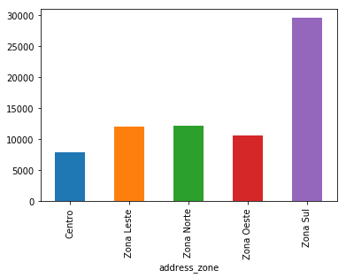

```python
train.groupby('address_zone')['address_neighborhood'].count().plot.bar()
```

**Pricing**

Assim como fizemos com a feature address, vamos realizar uma análise em cada componente de pricingInfos. Deixaremos a variável target para o final.

**1) pricingInfos_businessType**

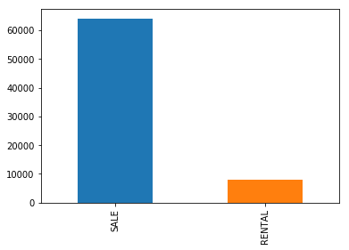

```python
train['pricingInfos_businessType'].value_counts().plot.bar()
plt.show()
```

Fica claro que a maior parte dos anúncios são de venda, sem nenhum valor para ambos. Como não temos interesse em anúncios de aluguel, o que pode gerar problemas na nossa predição, vamos deletá-los, mas antes vamos verificar se não houve problema de digitação, baseado no valor do aluguel.

```python
q = 'pricingInfos_businessType == "RENTAL" & pricingInfos_rentalTotalPrice == ""'
train.query(q).shape
# train.drop(train.query(q).index, inplace=True)
```

```
(0, 30)
```

Parece que os dados realmente se tratam de aluguel, logo não nos interessam.

```python
q = 'pricingInfos_businessType == "RENTAL"'
train.drop(train.query(q).index, inplace=True)
```

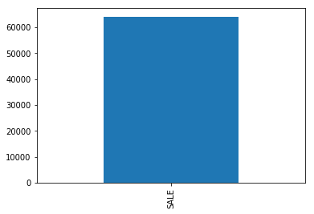

```python
train['pricingInfos_businessType'].value_counts().plot.bar()
plt.show()
```

**2) pricingInfos_monthlyCondoFee**

```python
train['pricingInfos_monthlyCondoFee'].isna().sum()
```

```
3628
```

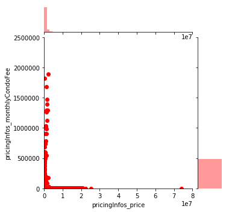

```python
plot = sns.jointplot(x='pricingInfos_price', y='pricingInfos_monthlyCondoFee', data=train, color='red', size=5)
plot.ax_marg_x.set_xlim(0, 80000000)
plot.ax_marg_y.set_ylim(0, 2500000)
plt.show()
```

A feature pricingInfos_monthlyCondoFee possui alguns valores nulos. Vamos substituí-los de acordo com sua localidade por Zona. Essa mesma tratativa será realizada no conjunto de teste.

```python
# essa função será utilizada sempre que for preciso setar um valor de acordo com a Zona do imóvel
def set_by_zone(var):
    return lambda x: math.floor(var['Centro']) if ('Centro' in x) \
            else math.floor(var['Zona Leste']) if ('Leste' in x) \
            else math.floor(var['Zona Norte']) if ('Norte' in x) \
            else math.floor(var['Zona Oeste']) if ('Oeste' in x) \
            else math.floor(var['Zona Sul'])
```

```python
mcf = train.groupby('address_zone')['pricingInfos_monthlyCondoFee'].mean()
train.loc[train['pricingInfos_monthlyCondoFee'].isna(), 'pricingInfos_monthlyCondoFee'] = train.loc[train['pricingInfos_monthlyCondoFee'].isna(), 'address_zone'].apply(set_by_zone(mcf))

mcf = test.groupby('address_zone')['pricingInfos_monthlyCondoFee'].mean()
test.loc[test['pricingInfos_monthlyCondoFee'].isna(), 'pricingInfos_monthlyCondoFee'] = test.loc[test['pricingInfos_monthlyCondoFee'].isna(), 'address_zone'].apply(set_by_zone(mcf))
```

De acordo com o gráfico, percebe-se que ela tem uma correlação mais neutra com a variável target, o que é mostrado pelo coeficiente de correlação de Pearson:

```python
print('Coeficente de correlação: ', train['pricingInfos_price'].corr(train['pricingInfos_monthlyCondoFee']))
```

```
Coeficente de correlação:  0.020173080373511086
```

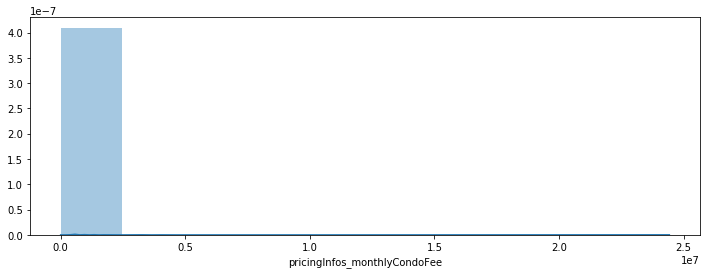

```python
plt.figure(figsize=(12,4))
sns.distplot(train['pricingInfos_monthlyCondoFee'], bins=10)
plt.show()
```

Podemos verificar que existem valores bem elevados para condominios. Vamos verificar algumas propriedades estatísticas dessa feature:

```python
train['pricingInfos_monthlyCondoFee'].describe().drop('count')
```

```
mean    2.016759e+03
std     1.044465e+05
min     0.000000e+00
25%     2.800000e+02
50%     5.030000e+02
75%     9.790000e+02
max     2.443000e+07
Name: pricingInfos_monthlyCondoFee, dtype: float64
```

```python
print('O valor médio de condomínio é: R${:.2f}'.format(train['pricingInfos_monthlyCondoFee'].mean()))
```

```
O valor médio de condomínio é: R$2016.76
```

**3) pricingInfos_period**

```python
train['pricingInfos_period'].value_counts()
```

```
MONTHLY    319
Name: pricingInfos_period, dtype: int64
```

```python
train.drop('pricingInfos_period', axis=1, inplace=True)
test.drop('pricingInfos_period', axis=1, inplace=True)
```

**4) pricingInfos_rentalTotalPrice**

Não temos interesse em valores de aluguel, inclusive os registros de anúncio com businessType RENTAL já foram deletados da nossa base de treino.

```python
train.drop('pricingInfos_rentalTotalPrice', axis=1, inplace=True)
test.drop('pricingInfos_rentalTotalPrice', axis=1, inplace=True)
```

```python
print('Train shape: ', train.shape)
print('Test shape: ', test.shape)
```

```
Train shape:  (64108, 28)
Test shape:  (16036, 28)
```

**5) pricingInfos_yearlyIptu**

```python
train['pricingInfos_yearlyIptu'].isna().sum()
```

```
9582
```

```python
q = 'pricingInfos_yearlyIptu == 0.0'
train.query(q)
```

|  | address_geoLocation_location_lat | address_geoLocation_location_lon | address_geoLocation_precision | address_locationId | address_neighborhood | address_streetNumber | address_zone | bathrooms | bedrooms | createdAt | description | id | images | listingStatus | owner | parkingSpaces | pricingInfos_businessType | pricingInfos_monthlyCondoFee | pricingInfos_price | pricingInfos_yearlyIptu | publicationType | publisherId | suites | title | totalAreas | unitTypes | updatedAt | usableAreas |
| --- | --- | --- | --- | --- | --- | --- | --- | --- | --- | --- | --- | --- | --- | --- | --- | --- | --- | --- | --- | --- | --- | --- | --- | --- | --- | --- | --- | --- |
| 9 | -23.568103 | -46.628405 | RANGE_INTERPOLATED | BR>Sao Paulo>NULL>Sao Paulo>Centro>Aclimacao | Aclimação | 140 | Centro | 4.0 | 4.0 | 2019-01-09T18:40:00.306Z | O apartamento tem 141 metros quadrados está lo... | 8e1922c386 | [https://vr-prod-vivapro-images.s3.amazonaws.c... | ACTIVE | False | 2.0 | SALE | 0.0 | 1106000 | 0.0 | PREMIUM | a9891875dd | 3.0 | Apartamento para venda com 141 metros quadrado... | 141.0 | APARTMENT | 2019-01-09T18:48:43.900Z | 141.0 |
| 21 | -23.664824 | -46.688407 | GEOMETRIC_CENTER | BR>Sao Paulo>NULL>Sao Paulo>Zona Sul>Jardim Ma... | Jardim Marajoara | 00 | Zona Sul | 2.0 | 3.0 | 2019-01-18T19:28:01.526Z | Apartamento para Venda Jardim Marajoara, São P... | 47e9737aaa | [https://vr-prod-vivapro-images.s3.amazonaws.c... | ACTIVE | False | 1.0 | SALE | 489.0 | 406000 | 0.0 | STANDARD | 38e4c3862b | 1.0 | Apartamento 86 m² para Venda com 3 dormitórios... | 86.0 | APARTMENT | 2019-01-18T19:28:08.343Z | 86.0 |
| 23 | -23.516717 | -46.712707 | GEOMETRIC_CENTER | BR>Sao Paulo>NULL>Sao Paulo>Zona Oeste>Lapa | Lapa | 555 | Zona Oeste | 4.0 | 4.0 | 2018-06-07T18:57:10.552Z | Pronto para morar! Última unidade\n\nChegou a ... | 10b25e3090 | [https://vr-prod-vivapro-images.s3.amazonaws.c... | ACTIVE | False | 2.0 | SALE | 0.0 | 683200 | 0.0 | STANDARD | b6c56b723f | 2.0 | Apto 134 m² 3 ou 4 dorms, Closet, 2 suítes, ... | 134.0 | APARTMENT | 2018-12-13T16:27:39.232Z | 134.0 |
| 24 | -23.617101 | -46.757218 | RANGE_INTERPOLATED | BR>Sao Paulo>NULL>Sao Paulo>Zona Sul>Jardim Um... | Jardim Umarizal | 21 | Zona Sul | 1.0 | 2.0 | 2018-01-19T11:30:52.702Z | Felipe\n Fone: - Nextel 55*97*132141 \n Whatss... | cbee3ce1f0 | [https://vr-prod-vivapro-images.s3.amazonaws.c... | ACTIVE | False | 1.0 | SALE | 210.0 | 157500 | 0.0 | STANDARD | a8b38b03a8 | 0.0 | Apartamento Atua Morumbi | 50.0 | APARTMENT | 2018-12-05T12:28:36.418Z | 50.0 |
| 25 | -23.598327 | -46.611316 | ROOFTOP | BR>Sao Paulo>NULL>Sao Paulo>Zona Sul>Vila Dom ... | Vila Dom Pedro I | 194 | Zona Sul | 1.0 | 1.0 | 2019-01-14T23:06:29.958Z | Apartamento localizado no ótimo bairro do Ipir... | 2348891a0d | [https://vr-prod-vivapro-images.s3.amazonaws.c... | ACTIVE | False | 1.0 | SALE | 0.0 | 193900 | 0.0 | STANDARD | c3526e68e6 | 0.0 | Apartamento com 1 Dormitorio - 1 Banheiro - 44... | 44.0 | APARTMENT | 2019-01-14T23:16:19.328Z | 44.0 |
| 27 | -23.567793 | -46.687788 | ROOFTOP | BR>Sao Paulo>NULL>Sao Paulo>Zona Oeste>Pinheiros | Pinheiros | 1057 | Zona Oeste | 1.0 | 1.0 | 2018-12-08T17:49:57.896Z | Studios de 30 á 40m², flets de 24 á 41m² e apa... | 67739c76ff | [https://vr-prod-vivapro-images.s3.amazonaws.c... | ACTIVE | False | 0.0 | SALE | 280.0 | 230221 | 0.0 | STANDARD | c3526e68e6 | 1.0 | Apartamento em Pinheiros próximo a metrô | 40.0 | APARTMENT | 2018-12-08T17:50:00.598Z | 30.0 |
| 28 | -23.587600 | -46.488497 | GEOMETRIC_CENTER | BR>Sao Paulo>NULL>Sao Paulo>Zona Leste>Jardim ... | Jardim Nove de Julho |  | Zona Leste | 1.0 | 2.0 | 2017-07-05T13:51:32.603Z | Lindo Apartamento para Venda - Jd. Nove de Jul... | 7ee2a005cb | [https://s3-sa-east-1.amazonaws.com/vr.images.... | ACTIVE | False | 1.0 | SALE | 161.0 | 175000 | 0.0 | STANDARD | 0801757c81 | 0.0 | Lindo Apartamento para Venda - Jd. Nove de Jul... | 45.0 | APARTMENT | 2019-01-10T13:18:09.414Z | 45.0 |
| 31 | -23.666044 | -46.717464 | RANGE_INTERPOLATED | BR>Sao Paulo>NULL>Sao Paulo>Zona Norte>Jardim ... | Jardim Japão | 516 | Zona Norte | 1.0 | 3.0 | 2018-09-01T01:20:55.671Z | O apartamento tem 78 metros quadrados está loc... | ebf708842f | [https://vr-prod-vivapro-images.s3.amazonaws.c... | ACTIVE | False | 1.0 | SALE | 342.0 | 258299 | 0.0 | STANDARD | a8b38b03a8 | 0.0 | Apartamento para venda possui 78 metros quadra... | 78.0 | APARTMENT | 2018-12-05T12:13:04.995Z | 78.0 |
| 34 | -23.597315 | -46.554757 | GEOMETRIC_CENTER | BR>Sao Paulo>NULL>Sao Paulo>Zona Leste>VILA AL... | Vila Alpina |  | Zona Leste | 1.0 | 2.0 | 2018-12-05T10:13:27.021Z | O apartamento possui 70 metros.\n2 dormitórios... | cdb501c35c | [https://vr-prod-vivapro-images.s3.amazonaws.c... | ACTIVE | False | 1.0 | SALE | 280.0 | 161000 | 0.0 | STANDARD | 260ba927d4 | 0.0 | Apartamento para venda | 0.0 | APARTMENT | 2018-12-05T10:13:32.895Z | 70.0 |
| 35 | -23.534171 | -46.579155 | RANGE_INTERPOLATED | BR>Sao Paulo>NULL>Sao Paulo>Zona Leste>Tatuape | Tatuapé | 101 | Zona Leste | 4.0 | 3.0 | 2018-12-26T15:41:44.949Z | No coração do Tatuapé:\n- 600 m do Parque do P... | 49255949c3 | [https://vr-prod-vivapro-images.s3.amazonaws.c... | ACTIVE | False | 2.0 | SALE | 0.0 | 427000 | 0.0 | STANDARD | c3526e68e6 | 3.0 | Apto 3 Suítes - Rua Ivai - The Gardens Reserva | 103.0 | APARTMENT | 2018-12-26T15:41:48.316Z | 103.0 |
| 36 | -23.568103 | -46.628405 | RANGE_INTERPOLATED | BR>Sao Paulo>NULL>Sao Paulo>Centro>Aclimacao | Aclimação | 140 | Centro | 4.0 | 4.0 | 2019-01-09T18:46:23.013Z | O apartamento tem 141 metros quadrados está lo... | 029392ddf8 | [https://vr-prod-vivapro-images.s3.amazonaws.c... | ACTIVE | False | 2.0 | SALE | 0.0 | 1106700 | 0.0 | PREMIUM | a9891875dd | 3.0 | Apartamento, para venda com 141 metros quadrad... | 141.0 | APARTMENT | 2019-01-09T18:49:03.814Z | 141.0 |
| 38 | -23.477879 | -46.708328 | ROOFTOP | BR>Sao Paulo>NULL>Sao Paulo>Zona Leste>Vila Re... | Vila Regina | 141 | Zona Leste | 1.0 | 3.0 | 2018-06-23T12:34:10.930Z | Apartamento localizado em Pirituba (Condomínio... | 2fed985fde | [https://vr-prod-vivapro-images.s3.amazonaws.c... | ACTIVE | False | 1.0 | SALE | 244.0 | 171500 | 0.0 | STANDARD | b797f29a38 | 0.0 | APTO NO CONDOMÍNIO LA DOLCE VITA - 3 DORMS, 1... | 0.0 | APARTMENT | 2018-11-08T13:34:24.263Z | 60.0 |
| 49 | -23.848153 | -46.741433 | RANGE_INTERPOLATED | BR>Sao Paulo>NULL>Sao Paulo>Zona Leste>Cidade ... | Cidade Satélite Santa Bárbara | 700 | Zona Leste | 1.0 | 2.0 | 2019-01-15T19:49:50.303Z | Aqui você tem tudo o que precisa para viver be... | 200161d57d | [https://vr-prod-vivapro-images.s3.amazonaws.c... | ACTIVE | False | 1.0 | SALE | 0.0 | 147000 | 0.0 | STANDARD | ff14b6b33d | 0.0 | Residencial Futura - Zona Leste, novo, nunca h... | 43.0 | APARTMENT | 2019-01-15T19:49:54.101Z | 43.0 |
| 58 | -23.477804 | -46.593067 | ROOFTOP | BR>Sao Paulo>NULL>Sao Paulo>Zona Norte>Vila Nivi | Vila Nivi | 1046 | Zona Norte | 1.0 | 2.0 | 2018-03-29T12:41:13.855Z | Apartamento novo, único dono, pronto para mora... | 2b2ef032c0 | [http://static.nidoimovel.com.br/a516a87cfcaef... | ACTIVE | False | 2.0 | SALE | 374.0 | 290500 | 0.0 | STANDARD | b8613a24b4 | 1.0 | Apto novo 2 dorms 1 suíte 2 vgs 5Min Metro Tuc... | NaN | APARTMENT | 2018-12-10T14:51:58.635Z | 63.0 |
| 60 | -23.534574 | -46.479788 | RANGE_INTERPOLATED | BR>Sao Paulo>NULL>Sao Paulo>Zona Leste>Parque ... | Parque das Paineiras | 66 | Zona Leste | 1.0 | 2.0 | 2018-12-24T00:24:24.840Z | O apartamento está localizado no bairro Parque... | 0759a66d72 | [https://vr-prod-listings-downloader-images.s3... | ACTIVE | False | 0.0 | SALE | 70000.0 | 115499 | 0.0 | STANDARD | 2bfafc55fa | 0.0 | Apartamento com 2 quartos em Artur Alvim ao l... | NaN | APARTMENT | 2018-12-24T00:24:29.256Z | 35.0 |
| 62 | -23.650253 | -46.791561 | ROOFTOP | BR>Sao Paulo>NULL>Sao Paulo>Zona Sul>Jardim Ma... | Jardim Macedônia | 54 | Zona Sul | 1.0 | 2.0 | 2018-12-21T15:03:13.676Z | Área útil 57 M² \nÁrea de Serviço \n2 Dormitór... | 89de0dffab | [https://vr-prod-vivapro-images.s3.amazonaws.c... | ACTIVE | False | 1.0 | SALE | 251.0 | 147000 | 0.0 | STANDARD | 7de5d72bf9 | 0.0 | Apartamento - Jardim Macedônia - 2 Dormitórios... | 0.0 | APARTMENT | 2018-12-21T15:03:39.793Z | 57.0 |
| 71 | -23.645645 | -46.592561 | ROOFTOP | BR>Sao Paulo>NULL>Sao Paulo>Zona Sul>Vila Liviero | Vila Liviero | 561 | Zona Sul | 1.0 | 2.0 | 2015-10-28T17:24:50Z | Apartamento com 2 dormitórios, sala 2 ambiente... | 7826a4fa0b | [https://s3-sa-east-1.amazonaws.com/vr.images.... | ACTIVE | False | 1.0 | SALE | 168.0 | 178500 | 0.0 | STANDARD | 37bf982ff1 | 0.0 | Apartamento com quarenta e nove metros quadrad... | 49.0 | APARTMENT | 2018-11-08T16:11:15.656Z | 49.0 |
| 72 | -23.681442 | -46.792068 | ROOFTOP | BR>Sao Paulo>NULL>Sao Paulo>Zona Sul>Jardim Do... | Jardim Dom José | 180 | Zona Sul | 1.0 | 2.0 | 2018-11-01T13:23:11.291Z | O apartamento tem 48 metros quadrados está loc... | c5a187992f | [https://vr-prod-vivapro-images.s3.amazonaws.c... | ACTIVE | False | 1.0 | SALE | 210.0 | 136500 | 0.0 | STANDARD | a8b38b03a8 | 0.0 | Apartamento para venda. Com 48 metros quadrado... | 48.0 | APARTMENT | 2018-12-04T23:09:48.968Z | 48.0 |
| 74 | -23.598327 | -46.611316 | ROOFTOP | BR>Sao Paulo>NULL>Sao Paulo>Zona Sul>Vila Dom ... | Vila Dom Pedro I | 194 | Zona Sul | 1.0 | 2.0 | 2019-01-14T23:21:45.762Z | Apartamento localizado no ótimo bairro do Ipir... | aaa23f3c63 | [https://vr-prod-vivapro-images.s3.amazonaws.c... | ACTIVE | False | 1.0 | SALE | 0.0 | 210700 | 0.0 | STANDARD | c3526e68e6 | 0.0 | Apartamento com 56m² - 2 Dormitorios 1 Banheir... | 56.0 | APARTMENT | 2019-01-14T23:21:48.132Z | 56.0 |
| 80 | -23.609960 | -46.527602 | GEOMETRIC_CENTER | BR>Sao Paulo>NULL>Sao Paulo>Zona Leste>Vila Me... | Vila Mendes |  | Zona Leste | 2.0 | 3.0 | 2018-06-15T17:49:09.048Z | Apartamento padrão, 3 dormitório(s), 2 banheir... | 57ed8367fc | [https://vr-prod-vivapro-images.s3.amazonaws.c... | ACTIVE | False | 1.0 | SALE | 259.0 | 196000 | 0.0 | STANDARD | eaf71868ab | 0.0 | Apartamento padrão, 3 dormitórios | 0.0 | APARTMENT | 2019-01-14T17:12:54.392Z | 61.0 |
| 86 | -23.622137 | -46.677588 | ROOFTOP | BR>Sao Paulo>NULL>Sao Paulo>Zona Sul>Campo Belo | Campo Belo | 624 | Zona Sul | 1.0 | 1.0 | 2018-12-05T20:08:26.338Z | O projeto arquitetônico dos apartamentos a ven... | ce22d420b7 | [https://vr-prod-vivapro-images.s3.amazonaws.c... | ACTIVE | False | 1.0 | SALE | 0.0 | 373800 | 0.0 | STANDARD | ff14b6b33d | 0.0 | Cube Campo Belo - Lançamento, imperdível !! ót... | 50.0 | APARTMENT | 2018-12-05T20:08:29.644Z | 50.0 |
| 87 | -23.651848 | -46.718177 | RANGE_INTERPOLATED | BR>Sao Paulo>NULL>Sao Paulo>Zona Sul>Jardim Do... | Jardim Dom Bosco | 210 | Zona Sul | 1.0 | 2.0 | 2017-04-22T18:39:41.002Z |  | 25cd1e18ba | [http://www.fabiocoelhoimoveis.net/v2010/spane... | ACTIVE | False | 1.0 | SALE | 162.0 | 237999 | 0.0 | STANDARD | fbfacc7462 | 0.0 | Sao Paulo - Padrao - Jardim Dom Bosco | 54.0 | APARTMENT | 2018-12-28T18:06:12.528Z | 54.0 |
| 88 | -23.653164 | -46.747704 | ROOFTOP | BR>Sao Paulo>NULL>Sao Paulo>Zona Sul>Jardim Ca... | Jardim Casablanca | 530 | Zona Sul | 1.0 | 2.0 | 2018-08-31T23:18:49.037Z | O apartamento de 56 metros quadrados está loca... | 53870b9c1e | [https://vr-prod-vivapro-images.s3.amazonaws.c... | ACTIVE | False | 1.0 | SALE | 280.0 | 152523 | 0.0 | STANDARD | a8b38b03a8 | 0.0 | Apartamento para aluguel e venda. Com 56 metro... | 56.0 | APARTMENT | 2018-12-17T21:55:05.887Z | 56.0 |
| 92 | -23.622513 | -46.604187 | ROOFTOP | BR>Sao Paulo>NULL>Sao Paulo>Zona Sul>Vila Vera | Vila Vera | 850 | Zona Sul | 2.0 | 3.0 | 2018-12-28T13:33:22.837Z | O apartamento de 69 metros quadrados no bairro... | 16319f199e | [https://vr-prod-vivapro-images.s3.amazonaws.c... | ACTIVE | False | 1.0 | SALE | 461.0 | 336000 | 0.0 | STANDARD | f5930da1d1 | 1.0 | Apartamento para venda tem 69 metros quadrados... | 0.0 | APARTMENT | 2018-12-28T13:35:44.464Z | 69.0 |
| 94 | NaN | NaN | NaN | BR>Sao Paulo>NULL>Sao Paulo>Zona Sul>Vila Sofia | Vila Emir | 4350 | Zona Sul | 1.0 | 2.0 | 2016-11-11T14:21:11Z | O apartamento tem 50 metros quadrados está loc... | 278c9151b0 | [https://s3-sa-east-1.amazonaws.com/vr.images.... | ACTIVE | False | 1.0 | SALE | 237.0 | 182000 | 0.0 | STANDARD | e69fe8aebc | 0.0 | Residencial Sabara/ SP | 50.0 | APARTMENT | 2018-11-29T16:39:34.934Z | 50.0 |
| 98 | -23.479819 | -46.583414 | ROOFTOP | BR>Sao Paulo>NULL>Sao Paulo>Zona Norte>Jardim ... | Jardim Brasil (Zona Norte) | 106 | Zona Norte | 0.0 | 2.0 | 2017-04-19T14:44:19.071Z | Apartamento Travessa da Av. Julio Buono, próxi... | dc973443eb | [http://static.nidoimovel.com.br/a516a87cfcaef... | ACTIVE | False | 1.0 | SALE | 261.0 | 206990 | 0.0 | STANDARD | b8613a24b4 | 0.0 | Apto 2 dorm.1vg 54,00m2. Ótima localização | 54.0 | APARTMENT | 2018-11-08T13:57:20.673Z | 54.0 |
| 99 | -23.652446 | -46.756747 | ROOFTOP | BR>Sao Paulo>NULL>Sao Paulo>Zona Sul>Jardim Ge... | Jardim Germânia | 139 | Zona Sul | 1.0 | 2.0 | 2018-12-10T16:42:05.627Z | Excelente apartamento 2 dorms., sala, cozinha,... | 89726c6e0a | [https://vr-prod-vivapro-images.s3.amazonaws.c... | ACTIVE | False | 1.0 | SALE | 336.0 | 175000 | 0.0 | STANDARD | bb5926fff9 | 0.0 | Apartamento 2 dorms., Jardim Germania | 50.0 | APARTMENT | 2018-12-10T16:42:20.527Z | 50.0 |
| 108 | -23.532913 | -46.683093 | GEOMETRIC_CENTER | BR>Sao Paulo>NULL>Sao Paulo>Zona Oeste>Perdizes | Perdizes |  | Zona Oeste | 4.0 | 3.0 | 2018-12-13T20:15:36.166Z | Ótimo apartamento, bem localizado, finamente ... | 8502c6b5ce | [https://vr-prod-vivapro-images.s3.amazonaws.c... | ACTIVE | False | 2.0 | SALE | 0.0 | 686000 | 0.0 | STANDARD | 068fd7f334 | 1.0 | Apartamento para venda 102 metros 3 quartos em... | 200.0 | APARTMENT | 2018-12-13T20:15:39.263Z | 102.0 |
| 110 | -23.616918 | -46.733063 | ROOFTOP | BR>Sao Paulo>NULL>Sao Paulo>Zona Oeste>Vila Su... | Vila Suzana | 145 | Zona Oeste | 2.0 | 4.0 | 2018-02-08T18:29:04.723Z | EDIFICIO MAISON RIVE GAUCHE\n\nApartamento, 45... | a4f420882c | [https://vr-prod-vivapro-images.s3.amazonaws.c... | ACTIVE | False | 4.0 | SALE | 0.0 | 735165 | 0.0 | STANDARD | 0ee2c7df64 | 3.0 | OPORTUNIDADE- IMÓVEL ADJUDICADO CAIXA ECONÔM... | 0.0 | APARTMENT | 2018-12-13T19:11:08.400Z | 316.0 |
| 112 | -23.531685 | -46.705285 | ROOFTOP | BR>Sao Paulo>NULL>Sao Paulo>Zona Oeste>Vila Ip... | Vila Ipojuca | 385 | Zona Oeste | 2.0 | 2.0 | 2018-12-06T17:44:45.316Z | Oportunidade de venda apartamento 74 metros qu... | 7ee66ebc16 | [https://vr-prod-vivapro-images.s3.amazonaws.c... | ACTIVE | False | 2.0 | SALE | 0.0 | 532000 | 0.0 | STANDARD | af1440969b | 0.0 | Oportunidade de venda 74 m² | 0.0 | APARTMENT | 2018-12-06T17:47:06.616Z | 74.0 |
| ... | ... | ... | ... | ... | ... | ... | ... | ... | ... | ... | ... | ... | ... | ... | ... | ... | ... | ... | ... | ... | ... | ... | ... | ... | ... | ... | ... | ... |
| 133785 | -23.558917 | -46.548548 | ROOFTOP | BR>Sao Paulo>NULL>Sao Paulo>Zona Leste>Tatuape | Vila Mafra | 191 | Zona Leste | 1.0 | 2.0 | 2017-04-18T22:15:46.807Z | Infraestrutura completa de comercio e&lt;br&gt... | 6458900ae0 | [http://cdn1.valuegaia.com.br/_Fotos/356/490/8... | ACTIVE | False | 1.0 | SALE | 244.0 | 244999 | 0.0 | STANDARD | 1c4b59580a | 0.0 | Apartamento residencial à venda, Tatuapé, São ... | 62.0 | APARTMENT | 2019-02-20T04:07:24.424Z | 62.0 |
| 133793 | -23.558057 | -46.617500 | GEOMETRIC_CENTER | BR>Sao Paulo>NULL>Sao Paulo>Zona Sul>Cambuci | Cambuci |  | Zona Sul | 0.0 | 1.0 | 2017-09-28T21:28:10.888Z | Apartamento 1 dorm com 33 metros , sem vaga . ... | 885297a7f9 | [https://multimidia.lopes.com.br/256/169-IM171... | ACTIVE | False | 0.0 | SALE | 196.0 | 175000 | 0.0 | STANDARD | 0ec61496e4 | 0.0 | Apartamento-São Paulo-Cambuci \| Ref.: 169-IM17... | 33.0 | APARTMENT | 2018-11-08T16:08:10.059Z | 33.0 |
| 133799 | -23.557207 | -46.655636 | RANGE_INTERPOLATED | BR>Sao Paulo>NULL>Sao Paulo>Centro>Cerqueira C... | Jardim Paulista | 366 | Centro | 3.0 | 2.0 | 2018-11-19T18:47:22.560Z | Imóvel com 2 dormitórios e 1 suite com ar cond... | f7d420793d | [http://cdn1.valuegaia.com.br/watermark/agenci... | ACTIVE | False | 1.0 | SALE | 979.0 | 595000 | 0.0 | STANDARD | 54426957a5 | 1.0 | Apartamento 2 dormitórios, 1 suite, 83 m², 1 v... | 90.0 | APARTMENT | 2019-02-21T21:03:21.164Z | 83.0 |
| 133802 | -23.557511 | -46.762311 | RANGE_INTERPOLATED | BR>Sao Paulo>NULL>Sao Paulo>Zona Oeste>Cidade ... | Cidade São Francisco | 580 | Zona Oeste | 3.0 | 4.0 | 2019-01-20T23:40:30.961Z | ÓTIMO APARTAMENTO EM PLANTA FUNCIONAL, NO CON... | 29ea2b84c0 | [https://vr-prod-vivapro-images.s3.amazonaws.c... | ACTIVE | False | 2.0 | SALE | 420.0 | 594300 | 0.0 | STANDARD | f4c14fb9d0 | 2.0 | Apartamento para venda possui 109 metros quadr... | 0.0 | APARTMENT | 2019-01-21T00:02:32.877Z | 109.0 |
| 133809 | -23.557732 | -46.581528 | ROOFTOP | BR>Sao Paulo>NULL>Sao Paulo>Zona Leste>Mooca | Vila Bertioga | 491 | Zona Leste | 2.0 | 2.0 | 2019-01-30T20:46:50.947Z | APTO NA MOÓCA - 02 DORMS/01 SUITE -1 VAGA - 64... | d12b675664 | [http://cdn.vistahost.com.br/castanim/vista.im... | ACTIVE | False | 1.0 | SALE | 461.0 | 357000 | 0.0 | STANDARD | 0d8a4eceb9 | 1.0 | apto na moóca - 02 dorms/01 suite-01 vaga-64 m... | 64.0 | APARTMENT | 2019-02-07T22:05:43.375Z | 64.0 |
| 133812 | -23.556540 | -46.604418 | GEOMETRIC_CENTER | BR>Sao Paulo>NULL>Sao Paulo>Zona Leste>Mooca | Mooca |  | Zona Leste | 2.0 | 2.0 | 2016-08-12T21:08:49Z | Apartamento com uma sala ampliada, 2 dormitóri... | 1504ad315d | [https://lh3.googleusercontent.com/2X6YeGqox1l... | ACTIVE | False | 1.0 | SALE | 489.0 | 420000 | 0.0 | STANDARD | f92cabe7f8 | 1.0 | Apartamento residencial à venda, Mooca, São Pa... | 86.0 | APARTMENT | 2019-02-25T00:20:34.995Z | 86.0 |
| 133814 | -23.556204 | -46.679310 | GEOMETRIC_CENTER | BR>Sao Paulo>NULL>Sao Paulo>Centro>Cerqueira C... | Cerqueira César |  | Centro | 5.0 | 4.0 | 2018-03-17T14:01:29.932Z | O apartamento tem 157 metros quadrados está lo... | f93d2c36c3 | [https://vr-prod-vivapro-images.s3.amazonaws.c... | ACTIVE | False | 0.0 | SALE | 0.0 | 1638700 | 0.0 | STANDARD | 967d57ce20 | 3.0 | Apartamento para venda possui 157 metros quadr... | 0.0 | APARTMENT | 2018-11-08T15:02:53.953Z | 157.0 |
| 133825 | -23.556010 | -46.679061 | ROOFTOP | BR>Sao Paulo>NULL>Sao Paulo>Zona Oeste>Pinheiros | Pinheiros | 616 | Zona Oeste | 1.0 | 2.0 | 2019-01-18T04:10:18.547Z | Ecelente apartamento próximo ao Hospital das C... | 08507b3aa7 | [http://images.ingaiasites.com.br/phJdvFwyv5QJ... | ACTIVE | False | 1.0 | SALE | 280.0 | 403900 | 0.0 | STANDARD | e196a2927f | 0.0 | Exclusivo Apartamento com 2 dormitórios à vend... | NaN | APARTMENT | 2019-02-25T05:44:59.349Z | 51.0 |
| 133828 | -23.556672 | -46.576575 | RANGE_INTERPOLATED | BR>Sao Paulo>NULL>Sao Paulo>Zona Leste>Agua Rasa | Vila Regente Feijo | 1 | Zona Leste | 1.0 | 2.0 | 2018-11-28T20:58:20.945Z | 2 DORMITORIOS, SALA, COZINHA, 1 BANHEIRO, LAVA... | cafe932cc5 | [http://www.carboneimoveis.com.br/vista.imobi/... | ACTIVE | False | NaN | SALE | 0.0 | 153300 | 0.0 | STANDARD | 69ca10c568 | NaN | SãO PAULO - Padrão - AGUA RASA | 50.0 | APARTMENT | 2019-02-16T23:55:44.929Z | 30.0 |
| 133834 | -23.556784 | -46.680275 | GEOMETRIC_CENTER | BR>Sao Paulo>NULL>Sao Paulo>Zona Oeste>Vila Ma... | Vila Madalena | 0 | Zona Oeste | 2.0 | 2.0 | 2018-09-26T09:13:20.753Z | Olá, como vai? \n\nRegião tranquila e arboriza... | 5e814e8eb9 | [https://vr-prod-vivapro-images.s3.amazonaws.c... | ACTIVE | False | 1.0 | SALE | 0.0 | 647500 | 0.0 | PREMIUM | 108973bbfe | 1.0 | Apartamento Vila Madalena | 70.0 | APARTMENT | 2019-02-24T10:28:04.451Z | 70.0 |
| 133837 | -23.556693 | -46.608594 | ROOFTOP | BR>Sao Paulo>NULL>Sao Paulo>Zona Leste>Mooca | Mooca | 8 | Zona Leste | 1.0 | 2.0 | 2018-11-12T19:21:51.621Z | Lindo Apartamento em ótima localização na Moóc... | 7a4a9c68bc | [http://images.ingaiasites.com.br/32riuTSIBjlj... | ACTIVE | False | 1.0 | SALE | 237.0 | 235199 | 0.0 | STANDARD | e71b46fda0 | 0.0 | Apartamento com 2 dormitórios à venda, 47 m² p... | NaN | APARTMENT | 2019-02-25T02:33:32.374Z | 47.0 |
| 133843 | -23.556460 | -46.617562 | GEOMETRIC_CENTER | BR>Sao Paulo>NULL>Sao Paulo>Zona Leste>Mooca | Mooca |  | Zona Leste | 1.0 | 2.0 | 2017-09-19T16:07:09.895Z | VENDA MOOCACódigo AF1834V14211 Apartamento 2 d... | bc7a6c8fe7 | [http://www.andreafaleiro.com.br/imagens/imove... | ACTIVE | False | NaN | SALE | 133.0 | 189000 | 0.0 | STANDARD | 3e428df253 | NaN | Apartamento para Venda em São Paulo, Mooca, 2 ... | 43.0 | APARTMENT | 2019-02-07T16:50:50.938Z | 43.0 |
| 133844 | -23.556657 | -46.649861 | ROOFTOP | BR>Sao Paulo>NULL>Sao Paulo>Centro>Bela Vista | Bela Vista | 52 | Centro | 0.0 | 2.0 | 2017-09-21T04:54:30.114Z | Apartamento de 2 dormitórios, bem distribuídos... | cc23807d00 | [http://images.ingaiasites.com.br/i78nzDkEGV0P... | ACTIVE | False | 0.0 | SALE | 259.0 | 770000 | 0.0 | STANDARD | e196a2927f | 1.0 | Apartamento residencial à venda, Bela Vista, S... | 170.0 | APARTMENT | 2018-10-27T07:24:07.106Z | 170.0 |
| 133861 | -23.556843 | -46.652218 | ROOFTOP | BR>Sao Paulo>NULL>Sao Paulo>Centro>Bela Vista | Bela Vista | 1510 | Centro | 1.0 | 1.0 | 2018-09-03T04:53:35.784Z | Apartamento de 28 m² com cozinha, banheiro, to... | 1960ba4f99 | [http://cdn1.valuegaia.com.br/watermark/agenci... | ACTIVE | False | 1.0 | SALE | 308.0 | 233799 | 0.0 | STANDARD | 77fa75e1d1 | 0.0 | Excelente Oportunidade no Centro de São Paulo! | NaN | APARTMENT | 2019-02-25T06:11:16.951Z | 28.0 |
| 133865 | -23.556540 | -46.604418 | GEOMETRIC_CENTER | BR>Sao Paulo>NULL>Sao Paulo>Zona Leste>Mooca | Mooca |  | Zona Leste | 3.0 | 3.0 | 2018-11-20T18:42:49.846Z | apartamento - Mooca&lt;br&gt;&lt;br&gt;84 m2&l... | eabfa3172e | [http://cdn1.valuegaia.com.br/watermark/agenci... | ACTIVE | False | 2.0 | SALE | 489.0 | 448000 | 0.0 | STANDARD | e405b23a37 | 1.0 | Apartamento residencial à venda, Mooca, São Pa... | NaN | APARTMENT | 2019-02-25T03:57:01.261Z | 84.0 |
| 133877 | -23.555017 | -46.692109 | ROOFTOP | BR>Sao Paulo>NULL>Sao Paulo>Zona Oeste>Vila Ma... | Pinheiros | 1468 | Zona Oeste | 3.0 | 4.0 | 2019-01-16T00:45:09.190Z | Apartamento em ótimo estado de conservação , v... | d4e25354e9 | [https://lh3.googleusercontent.com/kt7GvVzTy7_... | ACTIVE | False | 2.0 | SALE | 1260.0 | 1050000 | 0.0 | STANDARD | 3499b030ba | 1.0 | Apartamento com 3 dormitórios à venda, 123 m² ... | NaN | APARTMENT | 2019-02-25T03:34:27.893Z | 123.0 |
| 133882 | -23.555627 | -46.665482 | RANGE_INTERPOLATED | BR>Sao Paulo>NULL>Sao Paulo>Centro>Higienopolis | Higienópolis | 700 | Centro | 0.0 | 4.0 | 2018-07-19T14:56:56.456Z | Maravilhoso apartamento, em rua arborizada e c... | d1e8dd208b | [http://static.nidoimovel.com.br/7750ca3559e5b... | ACTIVE | False | 4.0 | SALE | 0.0 | 2380000 | 0.0 | STANDARD | b82acfe985 | 2.0 | Maravilhoso apartamento em Higienópolis! | 202.0 | APARTMENT | 2018-10-27T05:43:27.213Z | 202.0 |
| 133897 | -23.555593 | -46.619823 | ROOFTOP | BR>Sao Paulo>NULL>Sao Paulo>Zona Leste>Mooca | Mooca | 206 | Zona Leste | 2.0 | 2.0 | 2018-12-21T17:45:25.306Z | APARTAMENTO TODO MOBILIADO COM MÓVEIS PLANEJAD... | 97b6767f9b | [http://static.nidoimovel.com.br/ec8956637a997... | ACTIVE | False | 1.0 | SALE | 266.0 | 273000 | 0.0 | STANDARD | a52731fda7 | 0.0 | APARTAMENTO LOCALIZADO PRÓXIMO METRÔ | NaN | APARTMENT | 2019-02-22T06:54:33.758Z | 63.0 |
| 133901 | -23.555943 | -46.644469 | ROOFTOP | BR>Sao Paulo>NULL>Sao Paulo>Centro>Bela Vista | Bela Vista | 469 | Centro | 1.0 | 2.0 | 2019-02-08T10:01:34.242Z | Apartamento na região central de São Paulo, pr... | be6298a842 | [https://vault.imob.online/u1303/properties/ph... | ACTIVE | False | 0.0 | SALE | 182.0 | 244999 | 0.0 | STANDARD | cef2bf09fa | 0.0 | Apartamento em São Paulo bairro Bela Vista | NaN | APARTMENT | 2019-02-23T12:56:43.042Z | 73.0 |
| 133919 | -23.555210 | -46.570010 | ROOFTOP | BR>Sao Paulo>NULL>Sao Paulo>Zona Leste>Vila Re... | Vila Regente Feijó | 42 | Zona Leste | 2.0 | 3.0 | 2018-05-10T14:31:21.894Z | Apartamento novo, nunca habitado, com sala par... | 4ac4b941f0 | [http://static.nidoimovel.com.br/e07413354875b... | ACTIVE | False | 2.0 | SALE | 560.0 | 525000 | 0.0 | STANDARD | c081737d20 | 1.0 | Apartamento novo com 3 dormitórios e varanda g... | NaN | APARTMENT | 2019-02-19T06:55:50.922Z | 91.0 |
| 133926 | -23.554735 | -46.648489 | ROOFTOP | BR>Sao Paulo>NULL>Sao Paulo>Centro>Bela Vista | Bela Vista | 1289 | Centro | 1.0 | 1.0 | 2019-01-30T12:47:01.614Z | Apartamento na Bela Vista, próximo ao Shopping... | f10b933dcd | [http://static.nidoimovel.com.br/310dcbbf4cce6... | ACTIVE | False | 0.0 | SALE | 301.0 | 217000 | 0.0 | STANDARD | 7ae519de70 | 0.0 | APARTAMENTO - BELA VISTA - UM DORMITÓRIO | 64.0 | APARTMENT | 2019-02-07T14:02:14.206Z | 64.0 |
| 133928 | -23.555400 | -46.601218 | GEOMETRIC_CENTER | BR>Sao Paulo>NULL>Sao Paulo>Zona Leste>Mooca | Mooca |  | Zona Leste | 2.0 | 3.0 | 2018-05-31T01:51:33.450Z | apto. c/ 73 m na Mooca, todo reformado, 3 dorm... | dd793be42b | [http://images.ingaiasites.com.br/KT3MB5YrCoFo... | ACTIVE | False | 0.0 | SALE | 271.0 | 224000 | 0.0 | STANDARD | 81886ac261 | 1.0 | Apartamento residencial à venda, Mooca, São Pa... | 73.0 | APARTMENT | 2019-02-24T23:10:43.455Z | 73.0 |
| 133936 | -23.554036 | -46.686339 | ROOFTOP | BR>Sao Paulo>NULL>Sao Paulo>Zona Oeste>Vila Ma... | Jardim das Bandeiras | 272 | Zona Oeste | 4.0 | 2.0 | 2018-08-18T09:20:18.986Z | A sofisticação e a pureza das linhas, a obsess... | d637b3be14 | [https://s3.amazonaws.com/uploaded.prod.corret... | ACTIVE | False | 3.0 | SALE | 0.0 | 1890010 | 0.0 | STANDARD | cab8990da8 | 2.0 | Apartamento residencial para venda, Vila Madal... | NaN | APARTMENT | 2019-02-22T05:55:59.179Z | 173.0 |
| 133939 | -23.554300 | -46.654266 | GEOMETRIC_CENTER | BR>Sao Paulo>NULL>Sao Paulo>Centro>Consolacao | Consolação |  | Centro | 2.0 | 2.0 | 2018-02-07T11:25:28.629Z | Características:Edifício modernizado por Retro... | b32b1040c0 | [http://www.nivelaimoveis.com.br/imagens/imove... | ACTIVE | False | 1.0 | SALE | 1970.0 | 630000 | 0.0 | STANDARD | 1e05c51f1f | NaN | Apartamento para Venda em São Paulo, Consolaçã... | NaN | APARTMENT | 2019-02-08T01:20:22.098Z | 120.0 |
| 133941 | -23.555759 | -46.568749 | ROOFTOP | BR>Sao Paulo>NULL>Sao Paulo>Zona Leste>Jardim ... | Vila Regente Feijó | 1221 | Zona Leste | 2.0 | 3.0 | 2017-04-13T04:44:49.877Z | Apartamento novo com 95m² , ótima localização,... | 5e5010b475 | [http://cdn1.valuegaia.com.br/watermark/agenci... | ACTIVE | False | 2.0 | SALE | 0.0 | 595000 | 0.0 | STANDARD | 8c5fadc679 | 1.0 | Oportunidade no Anália Franco | 95.0 | APARTMENT | 2019-02-24T22:35:02.743Z | 95.0 |
| 133946 | -23.554003 | -46.638944 | ROOFTOP | BR>Sao Paulo>NULL>Sao Paulo>Centro>Bela Vista | Bela Vista | 36 | Centro | 2.0 | 2.0 | 2018-12-14T05:12:54.752Z | Morar em um espaço modernos e contemporâneo, n... | 14da1cdaaa | [https://s3.amazonaws.com/uploaded.prod.corret... | ACTIVE | False | 1.0 | SALE | 0.0 | 519882 | 0.0 | STANDARD | 098ac7eaec | 1.0 | Apartamento residencial para venda, Bela Vista... | NaN | APARTMENT | 2019-02-25T06:08:02.439Z | 64.0 |
| 133948 | -23.555991 | -46.447444 | ROOFTOP | BR>Sao Paulo>NULL>Sao Paulo>Zona Leste>Vila Ca... | Vila Carmosina | 600 | Zona Leste | 1.0 | 2.0 | 2018-08-25T01:45:51.230Z | Apartamento 2 dormitórios Sala de estar e jant... | dd1744e64a | [http://images.ingaiasites.com.br/zyXPV9yopxwq... | ACTIVE | False | 1.0 | SALE | 230.0 | 175000 | 0.0 | STANDARD | 294c5fd1b4 | 0.0 | Apartamento residencial à venda, Itaquera, São... | 48.0 | APARTMENT | 2019-02-25T05:45:52.361Z | 48.0 |
| 133951 | -23.555303 | -46.453410 | APPROXIMATE | BR>Sao Paulo>NULL>Sao Paulo>Zona Leste>Vila Ca... | Vila Carmosina |  | Zona Leste | 1.0 | 2.0 | 2015-10-07T09:11:37Z | Lindo apto recém reformado , 02 quartos, sala ... | 91a135d7d2 | [https://cdn1.valuegaia.com.br/_Fotos/364/390/... | ACTIVE | False | 1.0 | SALE | 207.0 | 154000 | 0.0 | STANDARD | 938d1cd0af | 0.0 | Apartamento residencial à venda, Vila Carmosin... | NaN | APARTMENT | 2019-02-24T23:15:40.571Z | 52.0 |
| 133956 | -23.555991 | -46.447444 | ROOFTOP | BR>Sao Paulo>NULL>Sao Paulo>Zona Leste>Vila Ca... | Vila Carmosina | 600 | Zona Leste | 1.0 | 2.0 | 2017-10-07T15:17:07.148Z | Apartamento todo Reformado (Piso Laminado e P... | a83904ca6a | [http://images.ingaiasites.com.br/1d6Wvn6k9bBe... | ACTIVE | False | 1.0 | SALE | 244.0 | 171150 | 0.0 | STANDARD | b3cc06c1a0 | 0.0 | Apartamento residencial à venda, Vila Carmosin... | 900.0 | APARTMENT | 2019-02-15T18:36:55.565Z | 48.0 |
| 133959 | -23.554810 | -46.628530 | RANGE_INTERPOLATED | BR>Sao Paulo>NULL>Sao Paulo>Centro>Liberdade | Liberdade | 255 | Centro | 2.0 | 2.0 | 2018-11-28T03:58:31.388Z | Apartamento liberdade 2 dormitórios sendo 1 s... | d1fc7797a8 | [https://lh3.googleusercontent.com/IRZ56Mf_cMG... | ACTIVE | False | 1.0 | SALE | 210.0 | 249782 | 0.0 | STANDARD | 55a5643619 | 1.0 | Apartamento com 2 dormitórios à venda, 53 m² p... | NaN | APARTMENT | 2019-02-25T06:00:56.335Z | 53.0 |

20037 rows × 28 columns

Para o preço do IPTU, temos varios valores faltantes e nulos. Vamos fazer o que fizemos com a variavel de condomínio, pois é uma coluna que poderá ser importante para a nossa predição.

```python
yiptu = train.groupby('address_zone')['pricingInfos_yearlyIptu'].mean()
train.loc[train['pricingInfos_yearlyIptu'].isna(), 'pricingInfos_yearlyIptu'] = train.loc[train['pricingInfos_yearlyIptu'].isna(), 'address_zone'].apply(set_by_zone(yiptu))

yiptu = test.groupby('address_zone')['pricingInfos_yearlyIptu'].mean()
test.loc[test['pricingInfos_yearlyIptu'].isna(), 'pricingInfos_yearlyIptu'] = test.loc[test['pricingInfos_yearlyIptu'].isna(), 'address_zone'].apply(set_by_zone(yiptu))
```

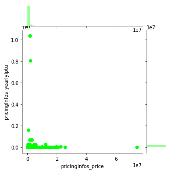

```python
sns.jointplot(x='pricingInfos_price', y='pricingInfos_yearlyIptu', data=train, color='lime', size=5)
plt.show()
```

De acordo com o gráfico, percebe-se que ela tem uma correlação mais neutra com a variável target, o que é mostrado pelo coeficiente de correlação de Pearson:

```python
print('Coeficente de correlação: ', train['pricingInfos_price'].corr(train['pricingInfos_yearlyIptu']))
```

```
Coeficente de correlação:  0.015893747588385816
```

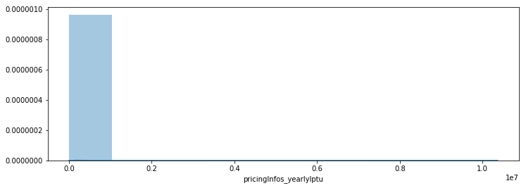

```python
plt.figure(figsize=(12,4))
sns.distplot(train['pricingInfos_yearlyIptu'], bins=10)
plt.show()
```

De acordo com o gráfico, existem anúncios para propriedades com IPTU anual acima dos R$10M. Vamos verificar algumas propriedades estatísticas dessa feature:

```python
train['pricingInfos_yearlyIptu'].describe().drop('count')
```

```
mean    8.958459e+02
std     5.256931e+04
min     0.000000e+00
25%     0.000000e+00
50%     1.200000e+02
75%     4.182500e+02
max     1.036700e+07
Name: pricingInfos_yearlyIptu, dtype: float64
```

```python
print('O valor médio do IPTU anual é: R${:.2f}'.format(train['pricingInfos_yearlyIptu'].mean()))
```

```
O valor médio do IPTU anual é: R$895.85
```

Dedicaremos uma sessão mais detalhada para a variável target, após analisarmos o restante das features.

**Outras features**

**1) bathrooms**

```python
print('null cnt bathrooms train: ', train['bathrooms'].isna().sum())
print('null cnt bathrooms test: ', test['bathrooms'].isna().sum())
```

```
null cnt bathrooms train:  1
null cnt bathrooms test:  1
```

Vamos substituir o valores nulos pela média de banheiros, para não perdemos informação nos dois conjuntos.

```python
train['bathrooms'].mean()
```

```
2.2621398599216933
```

```python
media = math.floor(train['bathrooms'].mean())
train['bathrooms'].fillna(media, inplace=True)

media = math.floor(test['bathrooms'].mean())
test['bathrooms'].fillna(media, inplace=True)
```

```python
train['bathrooms'].describe().drop('count')
```

```
mean     2.262136
std      1.662294
min      0.000000
25%      1.000000
50%      2.000000
75%      3.000000
max     99.000000
Name: bathrooms, dtype: float64
```

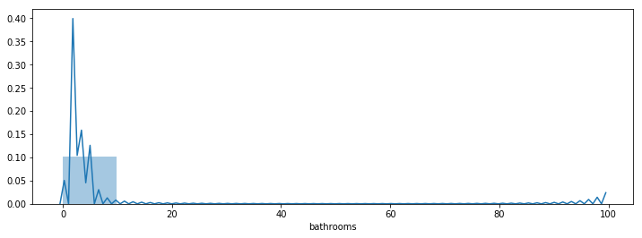

```python
plt.figure(figsize=(12,4))
sns.distplot(train['bathrooms'], bins=10)
plt.show()
```

A partir do gráfico de distribuição, podemos perceber que existem anúncios com varios banheiros no apartamento, o que parece fora do padrão.

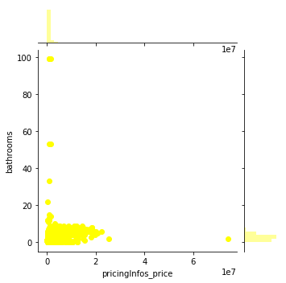

```python
sns.jointplot(x='pricingInfos_price', y='bathrooms', data=train, color='yellow', size=5)
plt.show()
```

```python
print('Coeficente de correlação: ', train['pricingInfos_price'].corr(train['bathrooms']))
```

```
Coeficente de correlação:  0.4545958639861393
```

O número de banheiros aparece com uma correlação mais positiva junto a variável target.

**2) bedrooms**

```python
print('null cnt bedrooms train: ', train['bedrooms'].isna().sum())
print('null cnt bedrooms test: ', test['bedrooms'].isna().sum())
```

```
null cnt bedrooms train:  0
null cnt bedrooms test:  0
```

Não possui valores nulos em nenhuma das bases.

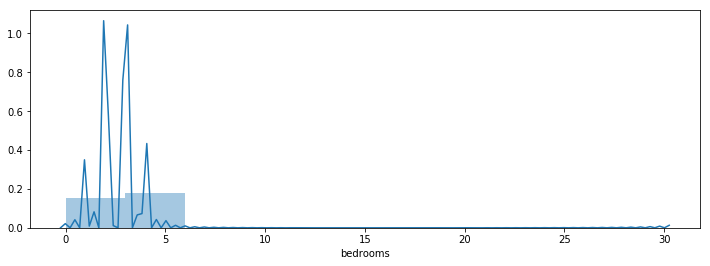

```python
plt.figure(figsize=(12,4))
sns.distplot(train['bedrooms'], bins=10)
plt.show()
```

```python
train['bedrooms'].describe().drop('count')
```

```
mean     2.577354
std      0.846875
min      0.000000
25%      2.000000
50%      3.000000
75%      3.000000
max     30.000000
Name: bedrooms, dtype: float64
```

Mais uma vez um número muito grande, 30 quartos. Mais a frente, durante a fase de feature engineering vamos analisar melhor esses valores discrepantes.

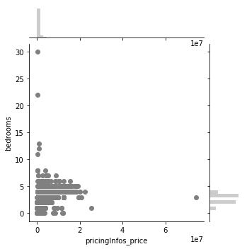

```python
sns.jointplot(x='pricingInfos_price', y='bedrooms', data=train, color='gray', size=5)
plt.show()
```

A variável bedrooms possui uma boa correlação com a variável target.

```python
print('Coeficente de correlação: ', train['pricingInfos_price'].corr(train['bedrooms']))
```

```
Coeficente de correlação:  0.4329215850715105
```

**3) owner**

```python
train['owner'].value_counts()
```

```
False    64091
True        17
Name: owner, dtype: int64
```

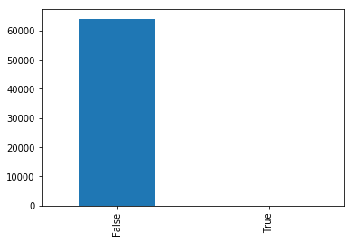

```python
train['owner'].value_counts().plot.bar()
plt.show()
```

Um dado bastante interessante! Apenas 17 dos anúncios foram criados pelos proprietários do imóvel. Isso pode estar relacionado ao fato de os proprietários preferirem a divulgação por meio de imobiliárias ou corretores de imóvel. Essa é uma boa informação para ofertar pacotes de divulgação de anúncios para as imobiliárias.

**4) parkingSpaces**

```python
print('null cnt parkingSpaces train: ', train['parkingSpaces'].isna().sum())
print('null cnt parkingSpaces test: ', test['parkingSpaces'].isna().sum())
```

```
null cnt parkingSpaces train:  1128
null cnt parkingSpaces test:  264
```

Vamos substituir os valores nulos pela média de vagas de garagem.

```python
media = math.floor(train['parkingSpaces'].mean())
train['parkingSpaces'].fillna(media, inplace=True)

media = math.floor(test['parkingSpaces'].mean())
test['parkingSpaces'].fillna(media, inplace=True)
```

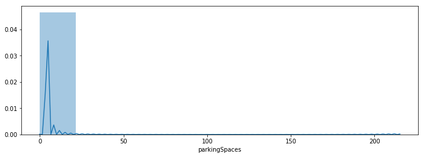

```python
plt.figure(figsize=(12,4))
sns.distplot(train['parkingSpaces'], bins=10)
plt.show()
```

```python
train['parkingSpaces'].describe().drop('count')
```

```
mean      1.738176
std       1.506804
min       0.000000
25%       1.000000
50%       1.000000
75%       2.000000
max     215.000000
Name: parkingSpaces, dtype: float64
```

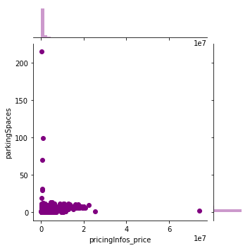

```python
sns.jointplot(x='pricingInfos_price', y='parkingSpaces', data=train, color='purple', size=5)
plt.show()
```

Pelo gráfico começamos a perceber uma correlação mais positiva da variável em questão com a target. A quantidade de garagens parece ser um bom atributo para calcular o preço do imóvel.

```python
print('Coeficente de correlação: ', train['pricingInfos_price'].corr(train['parkingSpaces']))
```

```
Coeficente de correlação:  0.47562623360014006
```

**5) publicationType**

```python
train['publicationType'].value_counts()
```

```
STANDARD    63094
PREMIUM      1014
Name: publicationType, dtype: int64
```

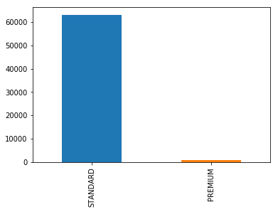

```python
train['publicationType'].value_counts().plot.bar()
plt.show()
```

A maioria absoluta dos anúncios são do tipo padrão como mostra o gráfico. Os dados categoricos importantes para nossa predição serão tratados posteriormente.

**6) suites**

```python
print('null cnt suites train: ', train['suites'].isna().sum())
print('null cnt suites test: ', test['suites'].isna().sum())
```

```
null cnt suites train:  5634
null cnt suites test:  1395
```

Existem diversos valores nulos. Vamos substituí-los pela média.

```python
media = math.floor(train['suites'].mean())
train['suites'].fillna(media, inplace=True)

media = math.floor(test['suites'].mean())
test['suites'].fillna(media, inplace=True)
```

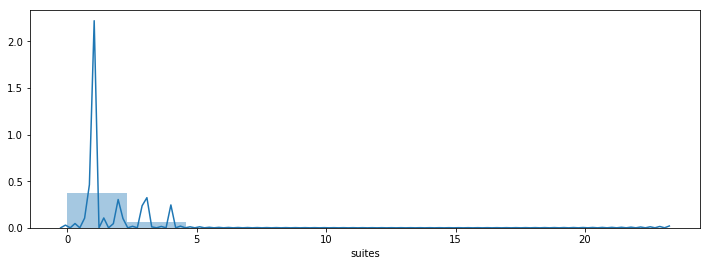

```python
plt.figure(figsize=(12,4))
sns.distplot(train['suites'], bins=10)
plt.show()
```

```python
train['suites'].describe().drop('count')
```

```
mean     1.157203
std      1.082923
min      0.000000
25%      0.000000
50%      1.000000
75%      1.000000
max     23.000000
Name: suites, dtype: float64
```

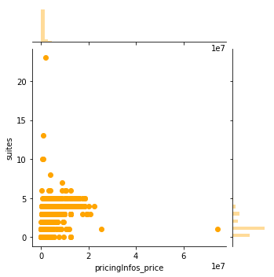

```python
sns.jointplot(x='pricingInfos_price', y='suites', data=train, color='orange', size=5)
plt.show()
```

Pelo gráfico começamos a perceber uma correlação mais positiva da variável suites com a pricingInfos_price. A quantidade de suites parece ter uma boa influencia sobre o valor do imóvel, sendo até agora a melhor variável de correlação com pricingInfos_price.

```python
print('Coeficente de correlação: ', train['pricingInfos_price'].corr(train['suites']))
```

```
Coeficente de correlação:  0.5701683441635822
```

**7) totalAreas**

```python
print('null cnt totalAreas train: ', train['totalAreas'].isna().sum())
print('null cnt totalAreas test: ', test['totalAreas'].isna().sum())
```

```
null cnt totalAreas train:  24941
null cnt totalAreas test:  6094
```

Temos muitos registros com valores nulos para essa coluna, que pode ser importante para a nossa predição. Podemos verificar a variavel usableAreas diferente de NaN e colocar o mesmo valor em totalAreas, caso usableAreas seja NaN também, podemos pegar a media de totalArea de acordo com a zona do imóvel.

```python
# treino
train.loc[train['totalAreas'].isna(), 'totalAreas'] = train.loc[train['totalAreas'].isna() & train['usableAreas'].notnull(), 'usableAreas']

tam = train.groupby('address_zone')['totalAreas'].mean()
train.loc[train['totalAreas'].isna(), 'totalAreas'] = train.loc[train['totalAreas'].isna(), 'address_zone'].apply(set_by_zone(tam))

# test
test.loc[test['totalAreas'].isna(), 'totalAreas'] = test.loc[test['totalAreas'].isna() & test['usableAreas'].notnull(), 'usableAreas']

tam = test.groupby('address_zone')['totalAreas'].mean()
test.loc[test['totalAreas'].isna(), 'totalAreas'] = test.loc[test['totalAreas'].isna(), 'address_zone'].apply(set_by_zone(tam))
```

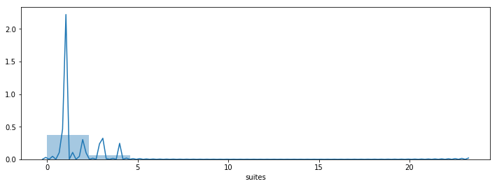

```python
plt.figure(figsize=(12,4))
sns.distplot(train['suites'], bins=10)
plt.show()
```

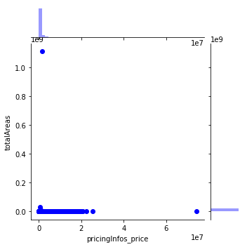

```python
sns.jointplot(x='pricingInfos_price', y='totalAreas', data=train, color='blue', size=5)
plt.show()
```

```python
train['totalAreas'].describe()
```

```
count    6.410800e+04
mean     1.846340e+04
std      4.390751e+06
min      0.000000e+00
25%      5.800000e+01
50%      8.400000e+01
75%      1.500000e+02
max      1.111111e+09
Name: totalAreas, dtype: float64
```

Apresenta uma correlação mais neutra com a variável target.

```python
print('Coeficente de correlação: ', train['pricingInfos_price'].corr(train['totalAreas']))
```

```
Coeficente de correlação:  0.002792377003813083
```

**8) usableAreas**

```python
print('null cnt usableAreas train: ', train['usableAreas'].isna().sum())
print('null cnt usableAreas test: ', test['usableAreas'].isna().sum())
```

```
null cnt usableAreas train:  8
null cnt usableAreas test:  7
```

A variável possui alguns valores nulos, vamos tratá-los da mesma forma que tratamos totalAreas.

```python
# treino
train.loc[train['usableAreas'].isna(), 'usableAreas'] = train.loc[train['usableAreas'].isna() & train['totalAreas'].notnull(), 'totalAreas']

# teste
test.loc[test['usableAreas'].isna(), 'usableAreas'] = test.loc[test['usableAreas'].isna() & test['totalAreas'].notnull(), 'totalAreas']
```

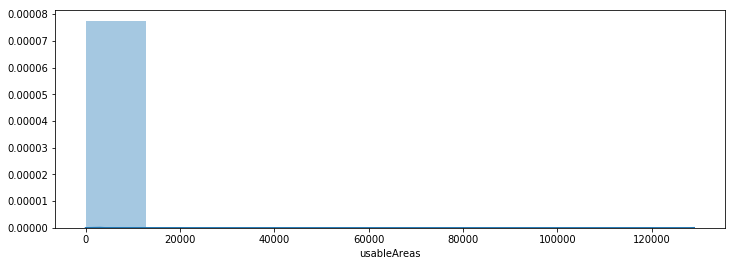

```python
plt.figure(figsize=(12,4))
sns.distplot(train['usableAreas'], bins=10)
plt.show()
```

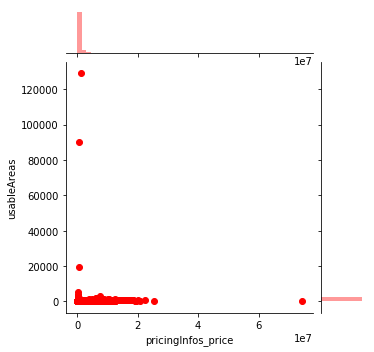

```python
sns.jointplot(x='pricingInfos_price', y='usableAreas', data=train, color='red', size=5)
plt.show()
```

Outra variável com uma correlação mais neutra com a variável target.

```python
print('Coeficente de correlação: ', train['pricingInfos_price'].corr(train['usableAreas']))
```

```
Coeficente de correlação:  0.10768901679588865
```

## pricingInfos_price

Inicialmente, vamos ver um sumário das estatísticas da variável target

```python
train['pricingInfos_price'].describe().drop('count').apply(lambda x: format(x, 'f'))
```

```
mean      763533.063799
std      1047864.471113
min        10500.000000
25%       273000.000000
50%       465499.000000
75%       860335.000000
max     74200000.000000
Name: pricingInfos_price, dtype: object
```

Temos um menor preço 10 mil e o maior preço 74 milhões. Vamos verificar como a variável se distribui:

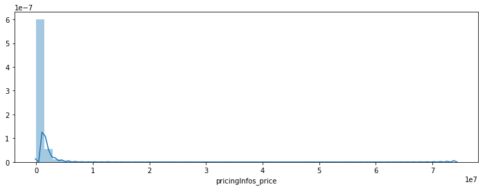

```python
plt.figure(figsize=(12,4))
sns.distplot(train['pricingInfos_price'])
plt.show()
```

Percebemos que a variável target tem uma distribuição distorcida positiva (Right-Skewed distribution). Nesses casos de right-skewed distribution, a média fica a direita do pico e mais a direita da mediana.

A distribuição normal é a distribuição mais fácil de trabalhar para obter um entendimento sobre estatísticas. Muitas distorções e técnicas estatísticas não funcionam. Como resultado, são utilizadas técnicas matemáticas avançadas, incluindo logaritmos e técnicas de regressão quantílica para transformar essas distribuições distorcidas em distribuições normais.

Vamos verificar algumas medidas da variável distribuída dessa forma:

```python
#skewness and kurtosis
print("Skewness: %f" % train['pricingInfos_price'].skew())
print("Kurtosis: %f" % train['pricingInfos_price'].kurt())
```

```
Skewness: 11.069836
Kurtosis: 437.402612
```

**Skewness** é o grau de distorção da curva simétrica ou da distribuição normal. Mede a falta de simetria na distribuição dos dados, diferenciando valores extremos. Uma distribuição simétrica terá skewness 0.

**Kurtosis** mostra tudo sobre a calda da distribuição. É usado para descrever os valores extremos, sendo na verdade a medida de outliers existentes na distribuição.

Percebemos um valor para o Kurtosis muito alto (High Kurtosis), indicando que temos muitos outliers.

De acordo com as análises percebemos que a maior parte das variáveis independentes também possuem uma right-skewed distribution.

### Relacionamento da variável alvo com as outras variáveis numéricas

Vamos estudar um pouco da correlação entre elas

```python
corr_matrix = train.corr()
corr_matrix['pricingInfos_price'].sort_values(ascending=False)
```

```
pricingInfos_price                  1.000000
suites                              0.570168
parkingSpaces                       0.475626
bathrooms                           0.454596
bedrooms                            0.432922
usableAreas                         0.107689
pricingInfos_monthlyCondoFee        0.020173
pricingInfos_yearlyIptu             0.015894
totalAreas                          0.002792
owner                              -0.005511
address_geoLocation_location_lon   -0.092388
address_geoLocation_location_lat   -0.125426
Name: pricingInfos_price, dtype: float64
```

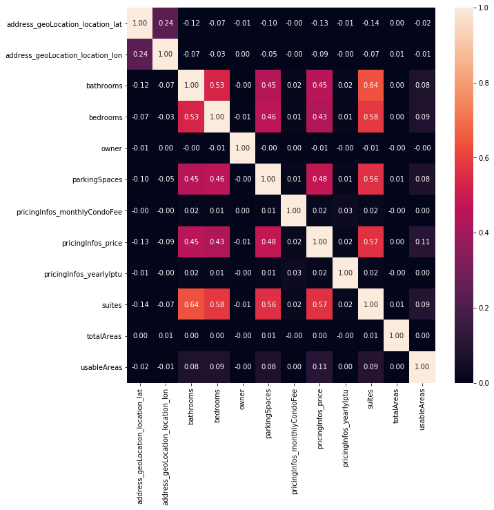

```python
fig, ax = plt.subplots(figsize=(10,10))
sns.heatmap(data=corr_matrix, annot=True, fmt='.2f', vmin=0, vmax=1, ax=ax)
plt.show()
```

As quatro variáveis que melhor se correlacionam com **pricingInfos_price** são suites, parkingSpaces, bathrooms, bedrooms.

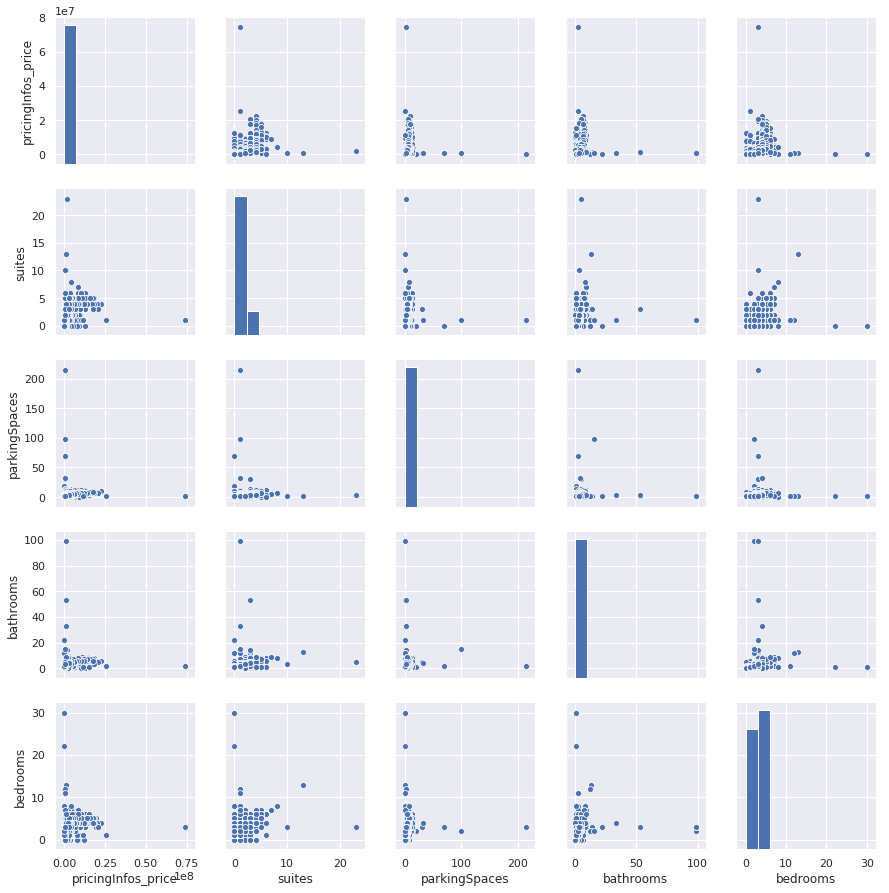

```python
sns.set()
cols = ['pricingInfos_price', 'suites', 'parkingSpaces', 'bathrooms', 'bedrooms']
sns.pairplot(train[cols], size=2.5)
plt.show()
```

### Relacionamento da variável alvo com as outras variáveis categoricas

```python
def create_boxplot(var):
    data = pd.concat([train['pricingInfos_price'], train[var]], axis=1)
    f, ax = plt.subplots(figsize=(5, 3))
    fig = sns.boxplot(x=var, y="pricingInfos_price", data=train)
    plt.xticks(rotation=90)
    fig.axis(ymin=0, ymax=9000000);
```

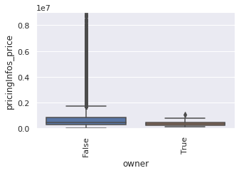

```python
create_boxplot('owner')
```

Como verificado anteriormente temos maior quantidade de anúncios que não foram divulgados pelos proprietários dos imóveis, talvez divulgados por corretores de imóveis. Percebemos, também, que boa parte dos anúncios não realizados pelos donos tem valores extremos.

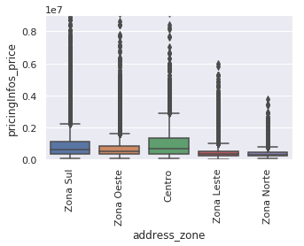

```python
create_boxplot('address_zone')
```

Aqui verificamos que os imóveis no Centro, Zona Sul e Zona Oeste, tem normalmente, os valores mais elevados. Vamos agrupar por zona e bairro para coletar uma informação mais precisa:

```python
train.groupby(['address_zone', 'address_neighborhood'])['pricingInfos_price'].mean().nlargest(n=10)
```

```
address_zone  address_neighborhood
Zona Oeste    Jardim Panorama                  1.274000e+07
Zona Sul      Jardim Universidade Pinheiros    1.155000e+07
              Retiro Morumbi                   1.059140e+07
              Cidade Jardim                    8.451100e+06
Zona Oeste    Vila Buenos Aires                7.140000e+06
              Jd Europa                        6.720000e+06
              Jardim Universidade Pinheiros    6.300000e+06
Zona Sul      Jardim Panorama                  6.155866e+06
Zona Leste    Jardim Nova Vitória II           5.950000e+06
Zona Oeste    Jardim Europa                    5.418674e+06
Name: pricingInfos_price, dtype: float64
```

O bairro Jardim Panorama, localizado na zona Oeste tem a maior media de valores de apartamentos.

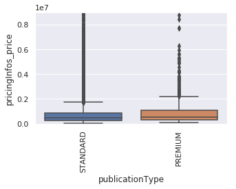

```python
create_boxplot('publicationType')
```

Enquanto o tipo de publicação padrão aparece com mais valores extremos, as publicações premium comumente são mais caras.

```python
for c in ['id', 'publisherId']:
    print(f'{c}:', train[c].nunique(), 'valores diferentes')
```

```
id: 64108 valores diferentes
publisherId: 2842 valores diferentes
```

Nenhum anúncio se repete, mas temos apenas 2842 anunciantes diferentes. Uma média de quase 23 anúncios por anunciante.

## Feature Engineering

Na realidade já fizemos algumas tratativas anteriores que se encaixariam nessa seção, como tratamento de valores faltantes ou nulos. Deixamos essa parte reservada para realizar as transformações nas features e para criação de novas features a partir de dados já existentes.

```python
#histogram and normal probability plot
def create_hist_prob_plot(ser):
    sns.distplot(ser, fit=norm);
    fig = plt.figure()
    res = stats.probplot(ser, plot=plt)
```

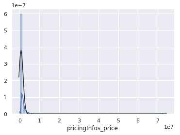

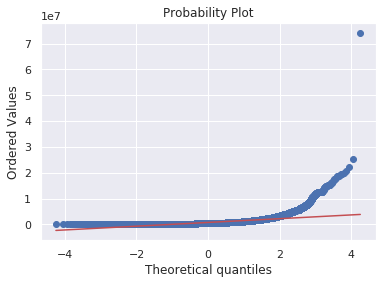

```python
create_hist_prob_plot(train['pricingInfos_price'])
```

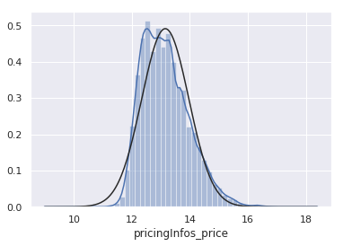

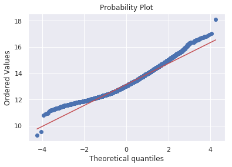

```python
# applying log transformation
train['pricingInfos_price'] = np.log(train['pricingInfos_price'])
create_hist_prob_plot(train['pricingInfos_price'])
```

### Tratando outliers

```python
train.columns
```

```
Index(['address_geoLocation_location_lat', 'address_geoLocation_location_lon',
       'address_geoLocation_precision', 'address_locationId',
       'address_neighborhood', 'address_streetNumber', 'address_zone',
       'bathrooms', 'bedrooms', 'createdAt', 'description', 'id', 'images',
       'listingStatus', 'owner', 'parkingSpaces', 'pricingInfos_businessType',
       'pricingInfos_monthlyCondoFee', 'pricingInfos_price',
       'pricingInfos_yearlyIptu', 'publicationType', 'publisherId', 'suites',
       'title', 'totalAreas', 'unitTypes', 'updatedAt', 'usableAreas'],
      dtype='object')
```

**bathrooms**

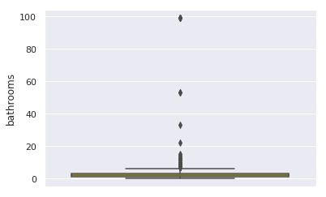

```python
sns.boxplot(y='bathrooms', data=train, color='yellow')
plt.show()
```

De acordo com o boxplot acima, percebemos que existem diversos valores extremos. Vamos dar uma analisada nesses pontos para saber se eles devem ser excluídos para evitar problemas na nossa predição.

```python
q = 'bathrooms > 15'
train.query(q).head()
```

|  | address_geoLocation_location_lat | address_geoLocation_location_lon | address_geoLocation_precision | address_locationId | address_neighborhood | address_streetNumber | address_zone | bathrooms | bedrooms | createdAt | description | id | images | listingStatus | owner | parkingSpaces | pricingInfos_businessType | pricingInfos_monthlyCondoFee | pricingInfos_price | pricingInfos_yearlyIptu | publicationType | publisherId | suites | title | totalAreas | unitTypes | updatedAt | usableAreas |
| --- | --- | --- | --- | --- | --- | --- | --- | --- | --- | --- | --- | --- | --- | --- | --- | --- | --- | --- | --- | --- | --- | --- | --- | --- | --- | --- | --- | --- |
| 5148 | -23.547160 | -46.653745 | ROOFTOP | BR>Sao Paulo>NULL>Sao Paulo>Centro>Higienopolis | Higienópolis | 247 | Centro | 99.0 | 2.0 | 2017-09-21T04:51:42.472Z |  | 547c0dd221 | [http://images.ingaiasites.com.br/uPcrknQZvrE9... | ACTIVE | False | 0.0 | SALE | 644.0 | 13.864301 | 122.0 | STANDARD | e196a2927f | 1.0 | Apartamento residencial à venda, Higienópolis,... | 178.0 | APARTMENT | 2018-10-27T07:22:56.607Z | 178.0 |
| 5642 | -23.646851 | -46.666001 | GEOMETRIC_CENTER | BR>Sao Paulo>NULL>Sao Paulo>Zona Sul>Vila Mascote | Vila Mascote |  | Zona Sul | 53.0 | 3.0 | 2016-05-13T06:24:39Z | COMPLETO, ÓTIMA OPORTUNIDADE, LOCALIZADO NO CO... | 9c22d1a4e1 | [http://wgc.quickfast.com/imoveisnovaopcao/fot... | ACTIVE | False | 1.0 | SALE | 553.0 | 13.864301 | 0.0 | STANDARD | afd2c39bce | 3.0 | Apartamento em São Paulo | 154.0 | APARTMENT | 2018-11-12T13:08:44.259Z | 154.0 |
| 10122 | -23.483635 | -46.701962 | GEOMETRIC_CENTER | BR>Sao Paulo>NULL>Sao Paulo>Zona Norte>Fregues... | Vila Marina |  | Zona Norte | 22.0 | 3.0 | 2017-09-15T06:54:30.090Z | apartamento Vila Iorio Freguesia do ó com 03 d... | aa4f3e40c7 | [http://images.ingaiasites.com.br/WblGFjcrPDMw... | ACTIVE | False | 1.0 | SALE | 350.0 | 12.409009 | 0.0 | STANDARD | dbea5f205d | 0.0 | Apartamento residencial à venda, Freguesia do ... | 65.0 | APARTMENT | 2018-11-08T12:56:34.531Z | 65.0 |
| 22853 | -23.610485 | -46.681161 | ROOFTOP | BR>Sao Paulo>NULL>Sao Paulo>Zona Sul>Brooklin | Brooklin Novo | 420 | Zona Sul | 33.0 | 4.0 | 2018-09-28T01:36:07.799Z | Bem localizado em meio ao "burburinho" do Broo... | 3afd269604 | [http://images.ingaiasites.com.br/lCiATX00Y9Nx... | ACTIVE | False | 3.0 | SALE | 1470.0 | 13.721200 | 0.0 | STANDARD | 8ce7f22dd6 | 1.0 | Brooklin apartamento a Venda 1 por Andar 3 Qua... | 121.0 | APARTMENT | 2018-11-20T00:31:42.874Z | 121.0 |
| 52422 | -23.542984 | -46.662513 | ROOFTOP | BR>Sao Paulo>NULL>Sao Paulo>Centro>Higienopolis | Higienópolis | 321 | Centro | 99.0 | 3.0 | 2017-09-21T04:53:39.352Z |  | b789ac42a3 | [http://images.ingaiasites.com.br/YWjJZnuruBpV... | ACTIVE | False | 1.0 | SALE | 1610.0 | 14.151983 | 0.0 | STANDARD | e196a2927f | 1.0 | Apartamento Residencial à venda, Higienópolis,... | 250.0 | APARTMENT | 2018-10-27T07:28:36.207Z | 250.0 |

Esse registros parecem outliers. Vamos removê-los.

```python
train.drop(train.query(q).index, inplace=True)
train.shape
```

```
(64100, 28)
```

**bedrooms**

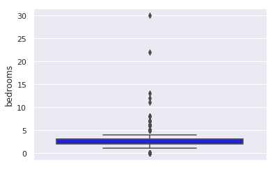

```python
sns.boxplot(y='bedrooms', data=train, color='blue')
plt.show()
```

```python
q = 'bedrooms > 15 & usableAreas < 300'
train.query(q)
```

|  | address_geoLocation_location_lat | address_geoLocation_location_lon | address_geoLocation_precision | address_locationId | address_neighborhood | address_streetNumber | address_zone | bathrooms | bedrooms | createdAt | description | id | images | listingStatus | owner | parkingSpaces | pricingInfos_businessType | pricingInfos_monthlyCondoFee | pricingInfos_price | pricingInfos_yearlyIptu | publicationType | publisherId | suites | title | totalAreas | unitTypes | updatedAt | usableAreas |
| --- | --- | --- | --- | --- | --- | --- | --- | --- | --- | --- | --- | --- | --- | --- | --- | --- | --- | --- | --- | --- | --- | --- | --- | --- | --- | --- | --- | --- |
| 85054 | -23.595875 | -46.561396 | APPROXIMATE | BR>Sao Paulo>NULL>Sao Paulo>Zona Leste>VILA AL... | Vila Alpina |  | Zona Leste | 1.0 | 30.0 | 2017-06-23T20:45:31.320Z | Apartamento na Costa Barros, 2299 com 3 dormit... | 7950ef588f | [http://www.brancoimoveisltda.com.br/fotos/622... | ACTIVE | False | 1.0 | SALE | 0.0 | 12.287653 | 0.0 | PREMIUM | c7c3abe952 | 0.0 | Apartamentos em Vila Alpina | 60.0 | APARTMENT | 2018-11-08T15:12:12.978Z | 60.0 |
| 114494 | -23.470982 | -46.653193 | ROOFTOP | BR>Sao Paulo>NULL>Sao Paulo>Zona Norte>Vila Am... | Vila Amélia | 175 | Zona Norte | 1.0 | 22.0 | 2018-10-20T09:33:05.840Z | APARTAMENTO LAUZANE PAULISTA!!&lt;br&gt;&lt;br... | 50e5e5d8cd | [https://s3-sa-east-1.amazonaws.com/grupo-unio... | ACTIVE | False | 1.0 | SALE | 241.0 | 12.138329 | 0.0 | STANDARD | 78ba763629 | 0.0 | APARTAMENTO RESIDENCIAL em SÃO PAULO - SP, VIL... | 60.0 | APARTMENT | 2018-10-27T08:07:18.851Z | 60.0 |

```python
train.drop(train.query(q).index, inplace=True)
train.shape
```

```
(64098, 28)
```

**parkingSpaces**

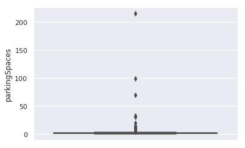

```python
sns.boxplot(y='parkingSpaces', data=train)
plt.show()
```

```python
q = 'parkingSpaces > 10'
train.query(q).shape
```

```
(24, 28)
```

Varias vagas de garagem num espaço de área pequeno. São valores extremos que devem ser deletados.

```python
train.drop(train.query(q).index, inplace=True)
train.shape
```

```
(64074, 28)
```

**suites**

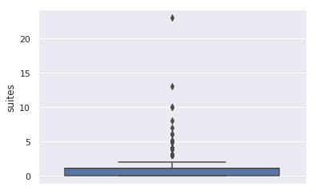

```python
sns.boxplot(y='suites', data=train)
plt.show()
```

```python
q = 'suites > 10'
train.query(q).head()
```

|  | address_geoLocation_location_lat | address_geoLocation_location_lon | address_geoLocation_precision | address_locationId | address_neighborhood | address_streetNumber | address_zone | bathrooms | bedrooms | createdAt | description | id | images | listingStatus | owner | parkingSpaces | pricingInfos_businessType | pricingInfos_monthlyCondoFee | pricingInfos_price | pricingInfos_yearlyIptu | publicationType | publisherId | suites | title | totalAreas | unitTypes | updatedAt | usableAreas |
| --- | --- | --- | --- | --- | --- | --- | --- | --- | --- | --- | --- | --- | --- | --- | --- | --- | --- | --- | --- | --- | --- | --- | --- | --- | --- | --- | --- | --- |
| 71220 | -23.511872 | -46.585783 | ROOFTOP | BR>Sao Paulo>NULL>Sao Paulo>Zona Norte>Vila Maria | Vila Maria Alta | 120 | Zona Norte | 13.0 | 13.0 | 2016-08-25T09:53:39Z | Imóvel situado na Vila Maria, fácil acesso par... | 3537ada880 | [https://ssl-w08cnn0135.websiteseguro.com/mira... | ACTIVE | False | 1.0 | SALE | 0.0 | 13.744013 | 0.0 | STANDARD | d7190e8f4c | 13.0 | Apartamento em Vila Maria - São Paulo, SP | 450.0 | APARTMENT | 2019-02-12T18:28:37.540Z | 450.0 |
| 88351 | -23.588872 | -46.672826 | ROOFTOP | BR>Sao Paulo>NULL>Sao Paulo>Zona Sul>Vila Nova... | Vila Nova Conceição | 55 | Zona Sul | 5.0 | 3.0 | 2019-02-08T12:37:21.047Z | Apto maravilhoso, pronto para mudar! Sala de e... | dbb5d65c99 | [http://static.nidoimovel.com.br/fde9264cf376f... | ACTIVE | False | 3.0 | SALE | 1599.0 | 14.523546 | 567.0 | STANDARD | 4daf3877a7 | 23.0 | Imóvel maravilhoso, excelente localização | 162.0 | APARTMENT | 2019-02-24T18:36:56.543Z | 162.0 |

```python
train.drop(train.query(q).index, inplace=True)
train.shape
```

```
(64072, 28)
```

**totalAreas**

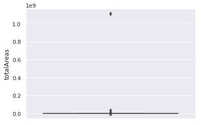

```python
sns.boxplot(y='totalAreas', data=train)
plt.show()
```

```python
q = 'totalAreas > 1e9'
train.query(q)
```

|  | address_geoLocation_location_lat | address_geoLocation_location_lon | address_geoLocation_precision | address_locationId | address_neighborhood | address_streetNumber | address_zone | bathrooms | bedrooms | createdAt | description | id | images | listingStatus | owner | parkingSpaces | pricingInfos_businessType | pricingInfos_monthlyCondoFee | pricingInfos_price | pricingInfos_yearlyIptu | publicationType | publisherId | suites | title | totalAreas | unitTypes | updatedAt | usableAreas |
| --- | --- | --- | --- | --- | --- | --- | --- | --- | --- | --- | --- | --- | --- | --- | --- | --- | --- | --- | --- | --- | --- | --- | --- | --- | --- | --- | --- | --- |
| 107792 | -23.544001 | -46.551719 | ROOFTOP | BR>Sao Paulo>NULL>Sao Paulo>Zona Leste>Tatuape | Chácara Santo Antônio (Zona Leste) | 22 | Zona Leste | 3.0 | 3.0 | 2018-07-06T05:06:59.474Z | Apartamento com 3 suítes, 3 salas, 4 vagas de ... | 56bc0d7530 | [http://images.ingaiasites.com.br/6WA6z295KUsr... | ACTIVE | False | 4.0 | SALE | 665.0 | 14.224303 | 630.0 | STANDARD | 11275cd82f | 3.0 | Apartamento á venda 3 dormitórios, Tatuapé | 1.111111e+09 | APARTMENT | 2019-02-25T04:44:44.886Z | 225.0 |

Esse registro tem um valor muito extremo, porém parece ter sido um erro de digitação. Vamos ajustá-lo para o mesmo valor de usableAreas:

```python
train.loc[train.query(q).index, 'totalAreas'] = 225.0
```

**usableAreas**

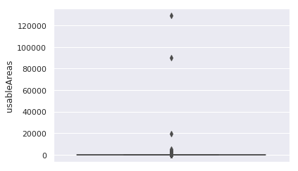

```python
sns.boxplot(y='usableAreas', data=train)
plt.show()
```

```python
q = 'usableAreas >= 15000'
train.query(q)
```

|  | address_geoLocation_location_lat | address_geoLocation_location_lon | address_geoLocation_precision | address_locationId | address_neighborhood | address_streetNumber | address_zone | bathrooms | bedrooms | createdAt | description | id | images | listingStatus | owner | parkingSpaces | pricingInfos_businessType | pricingInfos_monthlyCondoFee | pricingInfos_price | pricingInfos_yearlyIptu | publicationType | publisherId | suites | title | totalAreas | unitTypes | updatedAt | usableAreas |
| --- | --- | --- | --- | --- | --- | --- | --- | --- | --- | --- | --- | --- | --- | --- | --- | --- | --- | --- | --- | --- | --- | --- | --- | --- | --- | --- | --- | --- |
| 16201 | -23.611401 | -46.623216 | APPROXIMATE | BR>Sao Paulo>NULL>Sao Paulo>Zona Sul>Bosque da... | Bosque da Saúde |  | Zona Sul | 3.0 | 3.0 | 2018-06-21T23:11:01.088Z | ref. J-29192 - - Sacada - Deposito - Salão de ... | c2d1941966 | [http://www.akiimoveis.com.br/site/promo_venda... | ACTIVE | False | 3.0 | SALE | 1727.0 | 13.500937 | 847.0 | STANDARD | bd993d69a8 | 1.0 | Venda de COBERTURA DUPLEX - BOSQUE DA SAÚDE - ... | 19258.0 | APARTMENT | 2018-10-25T21:33:33.102Z | 19258.0 |
| 67973 | -23.475109 | -46.629271 | GEOMETRIC_CENTER | BR>Sao Paulo>NULL>Sao Paulo>Zona Norte>Mandaqui | Jardim Paraíso |  | Zona Norte | 3.0 | 3.0 | 2018-10-08T10:16:43.132Z | EDIFÍCIO PÁTIO SANTANA!!! Onde a vista e a fel... | 860cbb689c | [https://multimidia.lopes.com.br/462/170-IM348... | ACTIVE | False | 2.0 | SALE | 525.0 | 13.171154 | 0.0 | STANDARD | 0ec61496e4 | 1.0 | Apartamento-São Paulo-Jardim Paraíso \| Ref.: 1... | 90000.0 | APARTMENT | 2018-11-08T16:08:10.059Z | 90000.0 |
| 91585 | -23.615555 | -46.685058 | RANGE_INTERPOLATED | BR>Sao Paulo>NULL>Sao Paulo>Zona Sul>Brooklin | Itaim Bibi | 438 | Zona Sul | 2.0 | 2.0 | 2018-07-21T04:17:19.334Z | Excelente empreendimento Habitarte 2 com siste... | a7f483b850 | [http://static.nidoimovel.com.br/3dd48ab31d016... | ACTIVE | False | 2.0 | SALE | 1014.0 | 14.133157 | 0.0 | STANDARD | 75dca8cd95 | 1.0 | Condomínio Habitarte 2 - Rua Michigan | 129000.0 | APARTMENT | 2018-11-08T14:17:39.526Z | 129000.0 |

```python
train.drop(train.query(q).index, inplace=True)
train.shape
```

```
(64069, 28)
```

**pricingInfos_monthlyCondoFee**

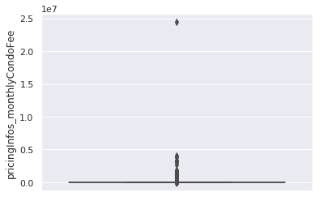

```python
sns.boxplot(y='pricingInfos_monthlyCondoFee', data=train)
plt.show()
```

```python
q = 'pricingInfos_monthlyCondoFee > 3000000'
train.query(q)
```

|  | address_geoLocation_location_lat | address_geoLocation_location_lon | address_geoLocation_precision | address_locationId | address_neighborhood | address_streetNumber | address_zone | bathrooms | bedrooms | createdAt | description | id | images | listingStatus | owner | parkingSpaces | pricingInfos_businessType | pricingInfos_monthlyCondoFee | pricingInfos_price | pricingInfos_yearlyIptu | publicationType | publisherId | suites | title | totalAreas | unitTypes | updatedAt | usableAreas |
| --- | --- | --- | --- | --- | --- | --- | --- | --- | --- | --- | --- | --- | --- | --- | --- | --- | --- | --- | --- | --- | --- | --- | --- | --- | --- | --- | --- | --- |
| 29655 | -23.597036 | -46.674606 | ROOFTOP | BR>Sao Paulo>NULL>Sao Paulo>Zona Sul>Itaim Bibi | Itaim Bibi | 88 | Zona Sul | 4.0 | 4.0 | 2018-03-21T13:45:12.382Z | Edifício residencial neoclássico no Itaim, ent... | 81c005b966 | [http://bossanova.sigavi360.com.br/Arquivo/Imo... | ACTIVE | False | 5.0 | SALE | 3273200.0 | 15.296206 | 1260.0 | STANDARD | d2adb7f92a | 4.0 | Apartamento Garden no Itaim | 455.0 | APARTMENT | 2019-02-07T21:20:23.293Z | 455.0 |
| 56832 | -23.538474 | -46.661330 | ROOFTOP | BR>Sao Paulo>NULL>Sao Paulo>Centro>Higienopolis | Santa Cecília | 1409 | Centro | 4.0 | 3.0 | 2018-10-26T18:29:54.726Z | Apartamento com 210 m², 3 suítes, sala em 3 a... | 42968cfc5c | [http://static.nidoimovel.com.br/1ecfb463472ec... | ACTIVE | False | 3.0 | SALE | 3072300.0 | 14.488455 | 1102.0 | STANDARD | 78101712f6 | 3.0 | Apartamento à venda de 210 m² - Higienópolis, ... | 210.0 | APARTMENT | 2019-02-24T07:38:11.089Z | 210.0 |
| 64153 | -23.553950 | -46.573049 | GEOMETRIC_CENTER | BR>Sao Paulo>NULL>Sao Paulo>Zona Leste>Vila Re... | Vila Regente Feijó |  | Zona Leste | 1.0 | 3.0 | 2018-03-27T20:10:00.590Z | Apartamento com 03 dormitorios 1 com suíte sal... | c3384a5768 | [http://cdn1.valuegaia.com.br/watermark/agenci... | ACTIVE | False | 0.0 | SALE | 4059999.0 | 12.914108 | 0.0 | STANDARD | 46d238593f | 1.0 | Apartamento residencial à venda, Vila Regente ... | 98.0 | APARTMENT | 2019-02-25T04:30:03.287Z | 98.0 |
| 96554 | -23.581327 | -46.687687 | ROOFTOP | BR>Sao Paulo>NULL>Sao Paulo>Zona Sul>Jardins | Jardim Europa | 52 | Zona Sul | 5.0 | 4.0 | 2018-03-24T00:00:23.854Z | Excelente Localização.&lt;br&gt;Região Nobre!&... | c9d54a0d9b | [https://www.jardimeuropaimoveis.com.br/export... | ACTIVE | False | 4.0 | SALE | 3842299.0 | 15.194906 | 9100.0 | STANDARD | 4ab6809aa6 | 2.0 | Apartamento no Jardins | 455.0 | APARTMENT | 2019-02-19T22:56:00.100Z | 455.0 |
| 104802 | -23.555240 | -46.693396 | RANGE_INTERPOLATED | BR>Sao Paulo>NULL>Sao Paulo>Zona Oeste>Alto de... | Alto de Pinheiros | 1600 | Zona Oeste | 6.0 | 4.0 | 2017-04-17T10:39:29.732Z | Edifício Domani, Alto de Pinheiros, com 4suite... | a15332a417 | [https://s3-sa-east-1.amazonaws.com/vr.images.... | ACTIVE | False | 4.0 | SALE | 24430000.0 | 15.033682 | 138.0 | STANDARD | 0b349f00ca | 4.0 | PINHEIRO/VILA MADALENA PÇA POR DO SOL | 298.0 | APARTMENT | 2019-02-03T13:33:13.075Z | 298.0 |
| 132319 | -23.563305 | -46.670848 | ROOFTOP | BR>Sao Paulo>NULL>Sao Paulo>Zona Sul>Jardim Am... | Cerqueira César | 3625 | Zona Sul | 5.0 | 3.0 | 2018-09-04T14:37:46.835Z | Apartamento a venda, Cerqueira César, Edif. Pa... | 1a381d949d | [http://static.nidoimovel.com.br/c3c59e5f8b3e9... | ACTIVE | False | 2.0 | SALE | 3329200.0 | 14.939303 | 862.0 | STANDARD | 48caa55c81 | 3.0 | Apartamento a venda, Cerqueira César, Edif. Pa... | 340.0 | APARTMENT | 2019-02-24T07:35:31.181Z | 340.0 |

```python
train.drop(train.query(q).index, inplace=True)
train.shape
```

```
(64063, 28)
```

**pricingInfos_yearlyIptu**

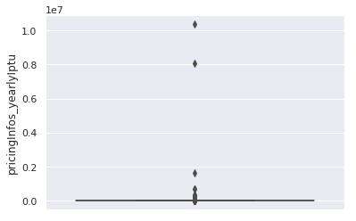

```python
sns.boxplot(y='pricingInfos_yearlyIptu', data=train)
plt.show()
```

```python
q = 'pricingInfos_yearlyIptu > 1500000'
train.query(q).shape
```

```
(3, 28)
```

```python
train.drop(train.query(q).index, inplace=True)
train.shape
```

```
(64060, 28)
```

### Removendo colunas desnecessárias

Vamos juntar as duas bases para trabalhar de forma igual na criação e transformação de algumas features

```python
data = train.append(test, sort=False).reset_index(drop=True)
print('Train shape: ', train.shape)
print('Test shape: ', test.shape)
print('Data shape: ', data.shape)

del train, test
gc.collect()
```

```
Train shape:  (64060, 28)
Test shape:  (16036, 28)
Data shape:  (80096, 28)
```

```
23521
```

```python
cols = ['description', 'title', 'createdAt', 'listingStatus', 'updatedAt', 'images',
        'address_geoLocation_location_lat', 'address_geoLocation_location_lon', 'address_geoLocation_precision',
        'address_locationId', 'address_streetNumber',
        'pricingInfos_businessType', 'publicationType', 'id', 'publisherId', 'unitTypes']

data.drop(cols, axis=1, inplace=True)
```

```python
print("{} colunas numéricas, {} colunas categóricas".format(
    list(data.select_dtypes(include=[np.number]).shape)[1],
    list(data.select_dtypes(include = ['object']).shape)[1]))
```

```
8 colunas numéricas, 3 colunas categóricas
```

### Criação de novas features

Vamos tentar extrair mais informações dos dados já disponíveis sem precisar adicionar novos dados, apenas criando novas features a partir das existentes

```python
mapper = lambda x: 1 if x > 0 else 0
data['_hasSuites'] = data['suites'].apply(mapper)
data['_hasParkingSpaces'] = data['parkingSpaces'].apply(mapper)
data['_hasBathrooms'] = data['bathrooms'].apply(mapper)
data['_hasBedrooms'] = data['bedrooms'].apply(mapper)
```

```python
data.columns
```

```
Index(['address_neighborhood', 'address_zone', 'bathrooms', 'bedrooms',
       'owner', 'parkingSpaces', 'pricingInfos_monthlyCondoFee',
       'pricingInfos_price', 'pricingInfos_yearlyIptu', 'suites', 'totalAreas',
       'usableAreas', '_hasSuites', '_hasParkingSpaces', '_hasBathrooms',
       '_hasBedrooms'],
      dtype='object')
```

```python
def fillInf(df, val):
    numcols = df.select_dtypes(include='number').columns
    cols = numcols[numcols != 'pricinInfos_price']
    df[df == np.Inf] = np.NaN
    df[df == np.NINF] = np.NaN
    for c in cols: df[c].fillna(val, inplace=True)
```

```python
data['_usablePerTotalAreas'] = data['usableAreas'] / data['totalAreas']
data['_totalRooms'] = data['bathrooms'] + data['bedrooms']
data['_suitesPerRooms'] = data['suites'] / data['_totalRooms']
data['_totalRoomsPerUsableAreas'] = data['_totalRooms'] / data['usableAreas']
data['_parkingSpacesPerTotalAreas'] = data['parkingSpaces'] / data['totalAreas']

zone = data.groupby(['address_zone', 'address_neighborhood'])
data['_suitesPerc'] = zone['suites'].rank(pct=True)
data['_parkingSpacesPerc'] = zone['parkingSpaces'].rank(pct=True)
data['_bathroomsPerc'] = zone['bathrooms'].rank(pct=True)
data['_bedroomsPerc'] = zone['bedrooms'].rank(pct=True)

fillInf(data, 0.0)
```

### Tratando valores categóricos

```python
data.drop('address_neighborhood', axis=1, inplace=True)
```

```python
data.columns
```

```
Index(['address_zone', 'bathrooms', 'bedrooms', 'owner', 'parkingSpaces',
       'pricingInfos_monthlyCondoFee', 'pricingInfos_price',
       'pricingInfos_yearlyIptu', 'suites', 'totalAreas', 'usableAreas',
       '_hasSuites', '_hasParkingSpaces', '_hasBathrooms', '_hasBedrooms',
       '_usablePerTotalAreas', '_totalRooms', '_suitesPerRooms',
       '_totalRoomsPerUsableAreas', '_parkingSpacesPerTotalAreas',
       '_suitesPerc', '_parkingSpacesPerc', '_bathroomsPerc', '_bedroomsPerc'],
      dtype='object')
```

```python
data = pd.get_dummies(data, columns=['address_zone'])
data.head()
```

|  | bathrooms | bedrooms | owner | parkingSpaces | pricingInfos_monthlyCondoFee | pricingInfos_price | pricingInfos_yearlyIptu | suites | totalAreas | usableAreas | _hasSuites | _hasParkingSpaces | _hasBathrooms | _hasBedrooms | _usablePerTotalAreas | _totalRooms | _suitesPerRooms | _totalRoomsPerUsableAreas | _parkingSpacesPerTotalAreas | _suitesPerc | _parkingSpacesPerc | _bathroomsPerc | _bedroomsPerc | address_zone_ | address_zone_Centro | address_zone_Zona Leste | address_zone_Zona Norte | address_zone_Zona Oeste | address_zone_Zona Sul |
| --- | --- | --- | --- | --- | --- | --- | --- | --- | --- | --- | --- | --- | --- | --- | --- | --- | --- | --- | --- | --- | --- | --- | --- | --- | --- | --- | --- | --- | --- |
| 0 | 2.0 | 3.0 | False | 2.0 | 686.0 | 13.5139 | 1610.0 | 1.0 | 80.0 | 80.0 | 1 | 1 | 1 | 1 | 1.000000 | 5.0 | 0.200000 | 0.062500 | 0.025000 | 0.525584 | 0.724138 | 0.522247 | 0.758621 | 0 | 0 | 0 | 0 | 0 | 1 |
| 1 | 5.0 | 4.0 | False | 5.0 | 6230.0 | 15.8331 | 18900.0 | 4.0 | 332.0 | 3322.0 | 1 | 1 | 1 | 1 | 10.006024 | 9.0 | 0.444444 | 0.002709 | 0.015060 | 0.917962 | 0.930915 | 0.840242 | 0.850604 | 0 | 0 | 0 | 0 | 0 | 1 |
| 2 | 1.0 | 3.0 | False | 2.0 | 1120.0 | 13.3546 | 489.0 | 0.0 | 0.0 | 94.0 | 0 | 1 | 1 | 1 | 0.000000 | 4.0 | 0.000000 | 0.042553 | 0.000000 | 0.109907 | 0.749484 | 0.175439 | 0.759546 | 0 | 0 | 0 | 0 | 1 | 0 |
| 3 | 4.0 | 4.0 | False | 2.0 | 0.0 | 13.9163 | 0.0 | 3.0 | 141.0 | 141.0 | 1 | 1 | 1 | 1 | 1.000000 | 8.0 | 0.375000 | 0.056738 | 0.014184 | 0.843685 | 0.593168 | 0.780538 | 0.916149 | 0 | 1 | 0 | 0 | 0 | 0 |
| 4 | 0.0 | 4.0 | False | 3.0 | 1400.0 | 13.7212 | 6300.0 | 4.0 | 188.0 | 188.0 | 1 | 1 | 0 | 1 | 1.000000 | 4.0 | 1.000000 | 0.021277 | 0.015957 | 0.963812 | 0.782365 | 0.019878 | 0.907747 | 0 | 0 | 0 | 0 | 0 | 1 |

```python
data.shape
```

```
(80096, 29)
```

## Machine Learning

```python
from datetime import datetime
from sklearn.linear_model import ElasticNetCV, LassoCV, RidgeCV
from sklearn.ensemble import GradientBoostingRegressor
from sklearn.svm import SVR
from sklearn.pipeline import make_pipeline
from sklearn.preprocessing import RobustScaler
from sklearn.model_selection import KFold, cross_val_score
from sklearn.metrics import mean_squared_error
from mlxtend.regressor import StackingCVRegressor
from xgboost import XGBRegressor
from lightgbm import LGBMRegressor
```

Vamos separar o data novamente para podermos realizar o treinamento e em seguida fazer nossa previsão. Da para saber o que era conjunto de treino e teste antes da junção através da variável target, que no conjunto de testes tem valor nulo.

```python
X_train = data[data['pricingInfos_price'].notnull()].reset_index(drop=True)
X_test = data[data['pricingInfos_price'].isnull()].drop(['pricingInfos_price'], axis=1).reset_index(drop=True)

y_train = X_train.pop('pricingInfos_price')
```

Vamos utilizar o Kfold para realizar um cross validation e definir nossa métrica.

```python
kfolds = KFold(n_splits=5, shuffle=True, random_state=42)

def rmsle(y, y_pred):
    return np.sqrt(mean_squared_error(y, y_pred))

def cv_rmse(model, X=X_train.iloc[:len(y_train), :]):
    rmse = np.sqrt(-cross_val_score(model, X, y_train, scoring="neg_mean_squared_error", cv=kfolds))
    return (rmse)
```

A métrica escolhida foi a Root Mean Squared Logarithmic Error, que é uma variação do Mean Squared Error. Introduzir o logaritmo faz com que essa métrica se preocupe apenas com a diferença relativa entre o valor real e o predito, se preocupa apenas com a diferença percentual entre eles. Essa métrica é utilizada quando a variável target é normalmente distribuída e não se deseja que erros grandes sejam significativamente mais penalizados do que os pequenos, no caso em que o range da variável target é grande. A transformação log usada na variável target, torna ela mais próxima de uma distribuição normal e, dessa forma, erros na previsao de apartamentos mais caros e mais baratos afetarão o resultado igualmente.

```python
# conjunto de parametros de regularizacao a serem testados
alphas_alt = [14.5, 14.6, 14.7, 14.8, 14.9, 15, 15.1, 15.2, 15.3, 15.4, 15.5]
alphas2 = [5e-05, 0.0001, 0.0002, 0.0003, 0.0004, 0.0005, 0.0006, 0.0007, 0.0008]
e_alphas = [0.0001, 0.0002, 0.0003, 0.0004, 0.0005, 0.0006, 0.0007]
e_l1ratio = [0.8, 0.85, 0.9, 0.95, 0.99, 1]
```

Vamos declarar alguns modelos de regressão e ver os que se ajustam melhor aos nossos dados.

```python
ridge = make_pipeline(RobustScaler(), RidgeCV(alphas=alphas_alt, cv=kfolds))
lasso = make_pipeline(RobustScaler(), LassoCV(max_iter=1e7, alphas=alphas2, random_state=42, cv=kfolds))
elasticnet = make_pipeline(RobustScaler(), ElasticNetCV(max_iter=1e7, alphas=e_alphas, cv=kfolds, l1_ratio=e_l1ratio))
```

```python
lightgbm = LGBMRegressor(objective='regression',
                                       num_leaves=4,
                                       learning_rate=0.01,
                                       n_estimators=5000,
                                       max_bin=200,
                                       bagging_fraction=0.75,
                                       bagging_freq=5,
                                       bagging_seed=7,
                                       feature_fraction=0.2,
                                       feature_fraction_seed=7,
                                       verbose=-1,
                                       )
```

```python
xgboost = XGBRegressor(learning_rate=0.01,n_estimators=3460,
                                     max_depth=3, min_child_weight=0,
                                     gamma=0, subsample=0.7,
                                     colsample_bytree=0.7,
                                     objective='reg:linear', nthread=-1,
                                     scale_pos_weight=1, seed=27,
                                     reg_alpha=0.00006)
```

Vamos também utilizar uma forma de juntar o poder dos modelos utilizados para melhorar nossos resultados. Utilizaremos uma técnica de ensemble para combiná-los:

```python
stack_gen = StackingCVRegressor(regressors=(ridge, lasso, elasticnet, xgboost, lightgbm),
                                meta_regressor=xgboost,
                                use_features_in_secondary=True)
```

```python
score = cv_rmse(ridge)
print("Kernel Ridge score: {:.4f} ({:.4f})\n".format(score.mean(), score.std()), datetime.now(), )

score = cv_rmse(lasso)
print("LASSO: {:.4f} ({:.4f})\n".format(score.mean(), score.std()), datetime.now(), )

score = cv_rmse(elasticnet)
print("elastic net: {:.4f} ({:.4f})\n".format(score.mean(), score.std()), datetime.now(), )

score = cv_rmse(lightgbm)
print("lightgbm: {:.4f} ({:.4f})\n".format(score.mean(), score.std()), datetime.now(), )

score = cv_rmse(xgboost)
print("xgboost: {:.4f} ({:.4f})\n".format(score.mean(), score.std()), datetime.now(), )
```

```
Kernel Ridge score: 0.3573 (0.0191)
 2019-07-13 02:02:21.139946
LASSO: 0.3573 (0.0191)
 2019-07-13 02:02:42.339306
elastic net: 0.3573 (0.0191)
 2019-07-13 02:02:59.268105
lightgbm: 0.2501 (0.0029)
 2019-07-13 02:04:03.879729
[02:04:04] WARNING: /workspace/src/objective/regression_obj.cu:152: reg:linear is now deprecated in favor of reg:squarederror.
[02:05:42] WARNING: /workspace/src/objective/regression_obj.cu:152: reg:linear is now deprecated in favor of reg:squarederror.
[02:07:21] WARNING: /workspace/src/objective/regression_obj.cu:152: reg:linear is now deprecated in favor of reg:squarederror.
[02:08:58] WARNING: /workspace/src/objective/regression_obj.cu:152: reg:linear is now deprecated in favor of reg:squarederror.
[02:10:34] WARNING: /workspace/src/objective/regression_obj.cu:152: reg:linear is now deprecated in favor of reg:squarederror.
xgboost: 0.2335 (0.0032)
 2019-07-13 02:12:11.864754
```

```python
print('START Fit')
print(datetime.now(), 'StackingCVRegressor')
stack_gen_model = stack_gen.fit(np.array(X_train), np.array(y_train))
print(datetime.now(), 'elasticnet')
elastic_model_full_data = elasticnet.fit(X_train, y_train)
print(datetime.now(), 'lasso')
lasso_model_full_data = lasso.fit(X_train, y_train)
print(datetime.now(), 'ridge')
ridge_model_full_data = ridge.fit(X_train, y_train)
print(datetime.now(), 'xgboost')
xgb_model_full_data = xgboost.fit(X_train, y_train)
print(datetime.now(), 'lightgbm')
lgb_model_full_data = lightgbm.fit(X_train, y_train)
```

```
START Fit
2019-07-13 02:12:11.877993 StackingCVRegressor
[02:12:56] WARNING: /workspace/src/objective/regression_obj.cu:152: reg:linear is now deprecated in favor of reg:squarederror.
[02:14:32] WARNING: /workspace/src/objective/regression_obj.cu:152: reg:linear is now deprecated in favor of reg:squarederror.
[02:16:09] WARNING: /workspace/src/objective/regression_obj.cu:152: reg:linear is now deprecated in favor of reg:squarederror.
[02:17:46] WARNING: /workspace/src/objective/regression_obj.cu:152: reg:linear is now deprecated in favor of reg:squarederror.
[02:19:22] WARNING: /workspace/src/objective/regression_obj.cu:152: reg:linear is now deprecated in favor of reg:squarederror.
[02:21:59] WARNING: /workspace/src/objective/regression_obj.cu:152: reg:linear is now deprecated in favor of reg:squarederror.
[02:24:45] WARNING: /workspace/src/objective/regression_obj.cu:152: reg:linear is now deprecated in favor of reg:squarederror.
2019-07-13 02:26:54.884556 elasticnet
2019-07-13 02:26:59.601464 lasso
2019-07-13 02:27:06.367215 ridge
2019-07-13 02:27:08.478271 xgboost
[02:27:08] WARNING: /workspace/src/objective/regression_obj.cu:152: reg:linear is now deprecated in favor of reg:squarederror.
2019-07-13 02:29:08.027703 lightgbm
```

```python
def blend_models_predict(X):
    return ((0.1 * elastic_model_full_data.predict(X)) + \
            (0.1 * lasso_model_full_data.predict(X)) + \
            (0.1 * ridge_model_full_data.predict(X)) + \
            (0.25 * xgb_model_full_data.predict(X)) + \
            (0.2 * lgb_model_full_data.predict(X)) + \
            (0.25 * stack_gen_model.predict(np.array(X))))

print('RMSLE score on train data:')
print(rmsle(y_train, blend_models_predict(X_train)))
```

```
RMSLE score on train data:
0.2436490630957622
```

Utilizando o modelo que obteve melhor resultado, no caso o XGBoost, vamos plotar o gráfico de importancia de feature para definir quais são os 3 melhores campos para a previsão do valor do imóvel

```python
from xgboost import plot_importance
```

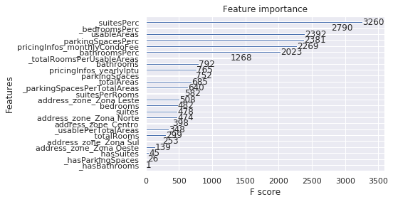

```python
plt.figure(figsize=(12,10))
plot_importance(xgb_model_full_data)
plt.show()
```

Prevendo os valores para o conjunto de teste e jogando no arquivo results.csv:

```python
results.iloc[:, 1] = np.floor(np.expm1(blend_models_predict(X_test)))
```

```python
results.shape
```

```
(16036, 2)
```

```python
results.head()
```

|  | id | price |
| --- | --- | --- |
| 0 | 89224365f8 | 384898.0 |
| 1 | 363731333f | 232039.0 |
| 2 | 6e6283378a | 487262.0 |
| 3 | 4c29a27f44 | 1062310.0 |
| 4 | 7b16cf224b | 460645.0 |

## Respostas as perguntas do desafio

1) Você utilizaria a métrica escolhida para seleção de modelo também para comunicar os resultados para usuários e stakeholders internos? Em caso negativo, qual outra métrica você utilizaria nesse caso?

R: Sim. Por se tratar de uma métrica variante da métrica Mean Squared Erro, que é mais fácil de ser compreendida, mostraria que a inclusão do log na função seria para que os erros em valores de apartamentos mais caros não influenciariam mais do que os erros em apartamentos mais baratos, penalizando igualmente.

2) Em quais bairros ou em quais faixas de preço o seu modelo performa melhor?

R: O modelo funciona igualmente para qualquer faixa de preço, exatamente por não ter diferença na penalização dos erros em valores maiores ou menores.

3) Se você tivesse que estimar o valor dos imóveis com apenas 3 campos, quais seriam eles?

R: Observando o gráfico de feature importance, utilizaria os campos _suitesPerc, _bedRoomsPerc e usableAreas, sendo os dois primeiros fruto da feature creation a partir do agrupamento por Zona e Bairro

4) Como você vislumbra colocar a sua solução em produção?

R: Para colocar o sistema em produção, poderiamos utilizar algum framework como Flask e sua extensão Flask Restful para a construção de uma API Rest, onde através de uma requisição o cliente enviaria via POST um array com as características do imóvel e receberia um valor para o imóvel.

```python
results.to_csv('results.csv', index=False)
```